# ClubReady Digital Insights Workshop

```r
if(!require(easypackages)){install.packages("easypackages")}
library(easypackages)
packages("plyr", "dplyr", "data.table", "xda","ggplot2", "forcats", "readr", "gridExtra", "knitr", "onehot", prompt = FALSE)
#data.table used only for fread
```

# Introduction

## Document Format

This document walks through the Digital Insight Workshop methodology to predict different churn models for ClubReady.

## Client Description

ClubReady LLC operates a Web based club management platform for fitness facilities, fitness individuals, and large corporate chains. It specializes in member management, billing, EFT and POS, and sales process/CRM. The company was incorporated in 2014 and is based in St. Louis, Missouri.

## Client Business Problem

ClubReady is currently the 3rd largest company in their industry. The company recognizes the need to take full advantage of their digital assets in an effort to gain deeper knowledge and understanding of customer behaviors. ClubReady has taken steps in this area to begin analyzing the significant data it captures through its membership software applications, and seeks support to further explore its data assets. ClubReady reached out to Valorem as a preferred Microsoft partner with expertise in Advanced Analytics, including Azure Machine Learning and the Cortana Intelligence Suite of Azure services.

ClubReady wants to become *a data-first* company focused on membership and member retention insights gained through an exploration of ClubReady data.

## Client Engagement

On October 3, 2017, ClubReady accepted a Valorem statement of work for a Digital Insight Workshop. The workshop provided the following deliverables

- Data Assessment and Quality Report
- Digital Analytics Vision & Roadmap of Actionable Insights
- Documented Key Priorities
- Potential Digital Insights Program ROI
- Recommended and Prioritized Analytics Actions
- Analytics Roadmap and Estimates
- Presentation of Next Steps

> As documented later in the report, these deliverables were collapsed into fewer deliverables as agreed during the inital on-site workshop meeting.

## Digital Insights Process

The Digital Insights Workshop Project flow includes:

1. Pre-Work and Agenda
2. On-Site Workshop
3. Analytics Run
4. Present Findings

> Analytics Run is renamed in this document to Exploratory Data Analysis

## Pre-Work and Agenda

On November 20, 2017, Valorem’s Project Manager led an introductory pre-workshop Skype Meeting. Andy Sweet, the ClubReady CTO and Project Sponsor participated with Valorem Data Scientists. The meeting consisted of:

- Team Introductions
- Project Overview
- Communications Plan
- Q & A

The core project Team Members were identified:

| Team Member | Company & Title |
| --- | --- |
| Andy Sweet | ClubReady CTO |
| Justin Trusty | ClubReady Data Architect |
| Lauren Crosby | ClubReady Director of Product Management |
| Matt Mercurio | ClubReady Director of Engineering |
| Brad Llewellyn | Valorem Data Scientist |
| Cliff Weaver | Valorem Data Scientist |
| Brian Roselli | Valorem Project Management |

## On-Site Workshop

The on-site workshop was help at ClubReady on November 28 - 29. The agenda presented at the workshop included:

- Day 1
  - ClubReady vision, goals, priorities
  - What can machine learning do for you?
  - Problem statements
  - Redefine deliverables
  - Churn Example
  - Data Sources & Definitions
- Day 2
  - Review previous day successes and misses
  - Data Exploration
  - Q&A
  - Time Permitting (Clients Choice)
  - Introduction to R

During the two-day workshop, the agenda was roughly followed. Regardless of the path, all the objectives to the workshop were accomplished:

- Understanding ClubReady goals and priorities
- Development of well-formed questions
- Review and Modification to Deliverables and Format
- Access to data
- Selection of data for analysis

### Understanding ClubReady Goals & Priorities

At the start of the on-site workshop, Andy Sweet provided an overview of ClubReady, its FY18 Goals and the mission to become a *data-first* company believing this will provide a strategic advantage over its competitors. (This section is intentionally kept brief because it is help for Valorem but provides no additional insights from ClubReady.)

### Well-Formed Question Development

The success of any data science project starts with a well-formed question. A well-formed question is a prerequisite to a project because without it, the project is highly likely to fail. At a minimum, a well-formed question provides:

A statement of the problem or issue that needs to be solved Detailed description of the data available for analysis. This includes data that is not not available. A description of what ClubReady would like to be able to predict or categorize What ClubReady will do when the answer from the last step is available

ClubReady wants to identify what clubs (full service and DIY) are likely to fail based on percentage drop in revenue

> Significant revenue percentage drop needs to be defined - currently defined as 80% drop in revenue from previous month

Member Churn is defined by an individual customer agreement termination with no renewal within 30 days.

ClubReady wants to identify the individual customer propensity at the club level (lowest organization in the hierarchy) to terminate their club agreement. (This excludes one-time users - ie not club members)

If a customer moves to an chain within the same owner hierarchy, need to check the change table to ID. So churn becomes: Agreement ends and not renewed in 30 days or club transfer

### Review and Modification to Diliverables and Format

The Statement of Work proferred the followin goutputs:

- Data Assessment and Quality Report
- Digital Analytics Vision & Roadmap of Actionable Insights
- Documented Key Priorities
- Potential Digital Insights Program ROI
- Recommended and Prioritized Analytics Actions
- Analytics Roadmap and Estimates
- Presentation of Next Steps

During the workshop, example documentation built using RMarkdown language saved in HTML format was presented. The ClubReady Team agreed this format was acceptable for all project reporting. (This document is the result of that agreement.)

### Access to ClubReady Data

On the 2nd day of the workshop, Valorem was granted and verified access to ClubReady data.

### Data Selection

ClubReady reviewed the tables and variables available in the ClubReady database (over 600 tables and 3,000+ fileds). It was quickly realized a majority of the fields were sparsely populated. The Team implemented custom SQL code to identify the sparsity of each variable. The Team then identified the initial set of candidate data ClubReady believed to be important to answer the well-formed questions.

#### Data Caveats & Assumptions

- There was no method to identify when data was populated. If a column was 60% dense, the filed would not have been selected even if that variable is 100% dense in the last year or two.
- There is no guarantee all impactful variables were identified. Reviewing a large dataset with a small Team does not ensure all important variables were included in the data used for modeling.
- Team determined the latest 2 years of data would be used for the project. It was in this period ClubReady experienced significant growth.

# Exploratory Data Analysis

This is the tactical execution results of the Exploratory Data Analysis process. Recall the `stores.csv` data file is explored first in detail followed by `ClassesService.csv` and `users.csv` with less commentary content.

This section walks through the initial Exploratory Data Analysis supporting the potential algorithm development to predict different churn models for ClubReady. The section is organized as follows:

- One of three CSV data files, stores.csv, is explored with detail in the first section
- In the following sections, the other two data files (User and Class & Services) are explored albeit with less explanatory content
- All of these sections roughly follow the same thought process:
  - Get Data
  - Remove/transform NAs
  - Character to Factors
  - Explore factors with tables and plots
  - Explore numerical data
  - Explore variances
  - Manage duplicate records
  - Data Glimpse

## Stores

### Get Data

Working with ClubReady, Valorem developed SQL scripts capturing raw data ClubReady data in csv format.

> Valorem learned from ClubReady some variables have no current business value. These have been removed from the working dataset.

```r
# deletedVars <- names(stores[grepl("^show", colnames(stores))])
# deletedVars <- ldply(deletedVars, data.frame)#convert list to DF
# names(deletedVars) <- "Deleted_Variables"
# stores  <-  stores[, !grepl("^show", colnames(stores))]
```

```r
#`r nrow(deletedVars)`
#deletedVars
```

### Categorical Variables

Lets look at the categorical variables first:

```r
charSummary(stores)
```

```
##                                               n miss miss% unique
## Status                                    42322    0     0      3
## AverageMinsPerClass_Service               42322    0     0     83
## AveragePricePerClass_Service              42322    0     0    772
## AverageCancellationHrsPerClass_Service    42322    0     0     36
## AverageRescheduleDeadlinePerClass_Service 42322    0     0     40
## AverageMinsPerClass                       42322    0     0     76
## AveragePricePerClass                      42322    0     0    495
## AverageCancellationHrsPerClass            42322    0     0     33
## AverageRescheduleDeadlinePerClass         42322    0     0     35
## AverageMinsPerService                     42322    0     0     57
## AveragePricePerService                    42322    0     0    471
## AverageCancellationHrsPerService          42322    0     0     35
## AverageRescheduleDeadlinePerService       42322    0     0     42
## UserEmployeeRatio                         42322    0     0   1446
## UserEmployeeRatio_Last3Months             42322    0     0   1326
##                                                                                                  top5levels:count
## Status                                                                    Active:37262, Inactive:4397, Cancel:663
## AverageMinsPerClass_Service                                        NULL:17693, 45:3120, 60:2182, 50:1775, 30:1597
## AveragePricePerClass_Service              NULL:17693, 0.000000:3183, 45.000000:1087, 20.000000:531, 57.500000:293
## AverageCancellationHrsPerClass_Service                               NULL:19039, 24:9395, 0:2152, 1:1592, 12:1549
## AverageRescheduleDeadlinePerClass_Service                            NULL:19039, 24:7588, 1:2221, 3:1673, 12:1500
## AverageMinsPerClass                                                 NULL:22835, 60:5776, 45:1656, 30:1263, 52:972
## AveragePricePerClass                       NULL:22835, 0.000000:3212, 20.000000:811, 10.000000:684, 25.000000:522
## AverageCancellationHrsPerClass                                        NULL:25858, 24:7273, 0:2713, 1:1893, 12:863
## AverageRescheduleDeadlinePerClass                                     NULL:25858, 24:5249, 1:2587, 3:1741, 2:1401
## AverageMinsPerService                                              NULL:20946, 45:4126, 40:1968, 60:1851, 50:1823
## AveragePricePerService                    NULL:20922, 0.000000:2916, 45.000000:1674, 30.000000:457, 60.000000:445
## AverageCancellationHrsPerService                                    NULL:21008, 24:9905, 0:2002, 16:1703, 12:1655
## AverageRescheduleDeadlinePerService                                 NULL:21008, 24:8306, 12:1636, 16:1589, 1:1484
## UserEmployeeRatio                                                       NULL:3274, 18:382, 21:346, 28:342, 23:338
## UserEmployeeRatio_Last3Months                                            NULL:2923, 7:412, 21:393, 25:393, 16:389
```

```r
stores <- stores %>% mutate_if(is.character, as.factor)
#charSummary(stores)
table(stores$Status)
```

```
##
##   Active   Cancel Inactive
##    37262      663     4397
```

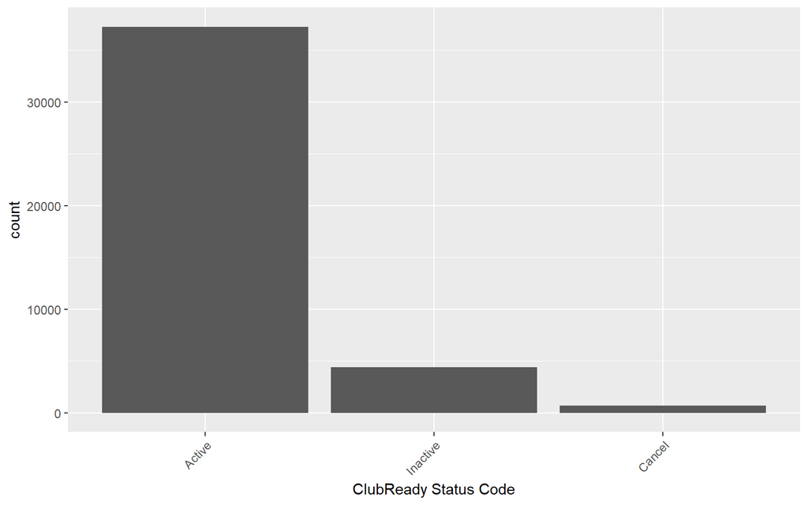

```r
ggplot(stores, aes(fct_infreq(Status))) + geom_bar() + xlab("ClubReady Status Code") + theme(axis.text.x = element_text(angle = 45, hjust = 1))
```

ClubReady provided direction on how to manage `Active`, `Inactive`, and `Cancel`:

*Inactive is a store that is no longer with ClubReady. Most likely left to go to competitor.* *Cancel is a store that was in the process of being setup and for some reason stopped.* *Ignore cancel.*

Remove records where `Status` is not either `Active` or `Inactive`.

```r
#starts with 5321, end with 4288 records
stores <-  filter(stores, Status == 'Active' | Status == 'Inactive')
table(stores$Status)
```

```
##
##   Active   Cancel Inactive
##    37262        0     4397
```

```r
stores$Status <- factor(stores$Status)
table(stores$Status)
```

```
##
##   Active Inactive
##    37262     4397
```

After removing the records associated with `Status` fields that are not needed, 41659 records remain.

### Numerical Data

```r
myNumSum <- numSummary(stores)[, c(1,7,8,16,17)]
myNumSum <- tibble::rownames_to_column(myNumSum)
names(myNumSum)[5] <- "missCNT"
names(myNumSum)[1] <- "Variable_Name"
myNumSum <- arrange(myNumSum, desc(n))
head(myNumSum, 20)
```

```
##                       Variable_Name     n nunique nzeros missCNT miss%
## 1                           StoreId 41659    2616      0       0     0
## 2                           IsChurn 41659       2  41078       0     0
## 3                   IsChurn_2Months 41659       2  40026       0     0
## 4                   IsChurn_3Months 41659       2  39602       0     0
## 5                   IsChurn_6Months 41659       2  38505       0     0
## 6                        SMSEnabled 41659       2      4       0     0
## 7                    StoreAgeMonths 41659     119    290       0     0
## 8                         Amenities 41659      28  30988       0     0
## 9            Integration_ABCCheckIn 41659       2  41224       0     0
## 10          Integration_ABCDataTrak 41659       2  41574       0     0
## 11               Integration_dotFit 41659       2  41259       0     0
## 12               Integration_FitBPO 41659       1  41659       0     0
## 13           Integration_fitRewards 41659       2  41252       0     0
## 14            Integration_Listen360 41659       2  30365       0     0
## 15           Integration_MotionSoft 41659       1  41659       0     0
## 16            Integration_Paramount 41659       1  41659       0     0
## 17            Integration_Perkville 41659       2  37633       0     0
## 18              Integration_PumpOne 41659       2  41634       0     0
## 19         Integration_ShareYourFit 41659       1  41659       0     0
## 20 Integration_VisualFitnessPlanner 41659       1  41659       0     0
```

Good, no missing data!

Examine the numerical data using plotting to illustrate interesting distributions.

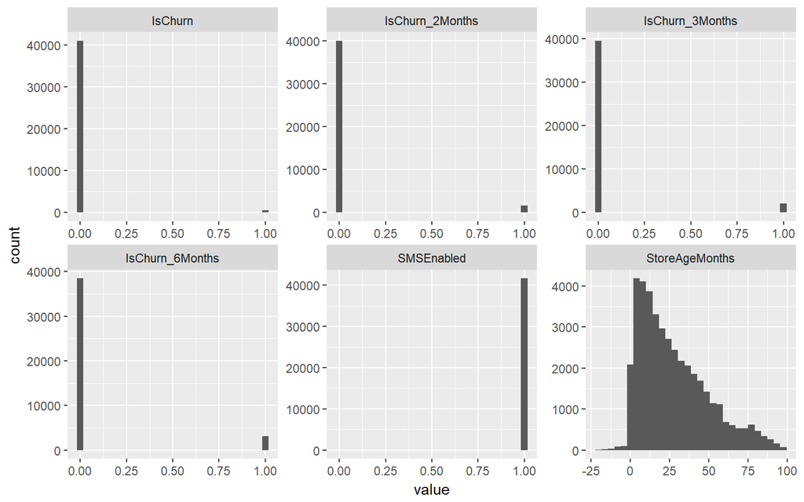

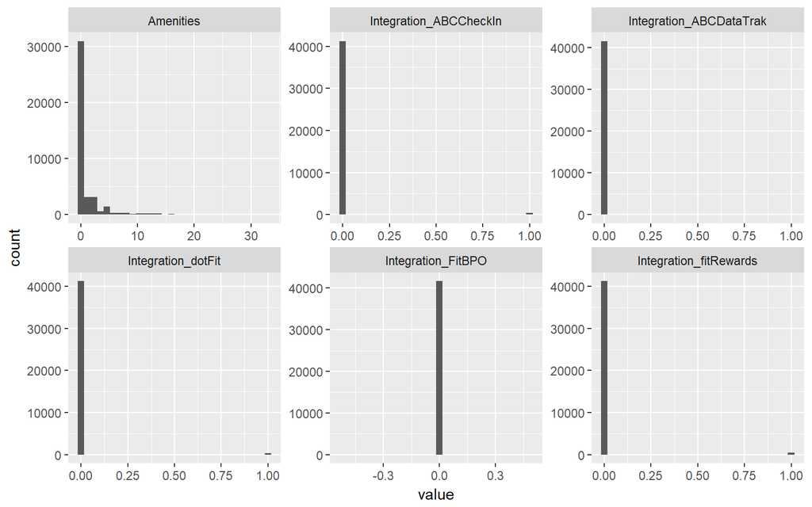

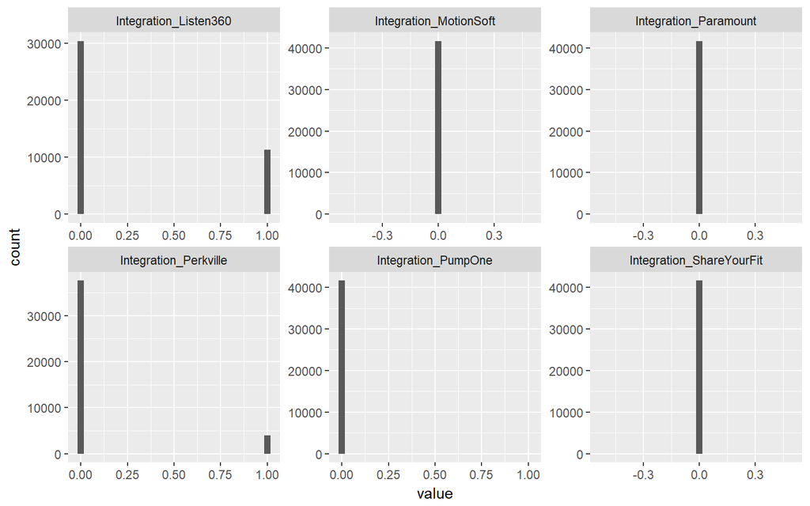

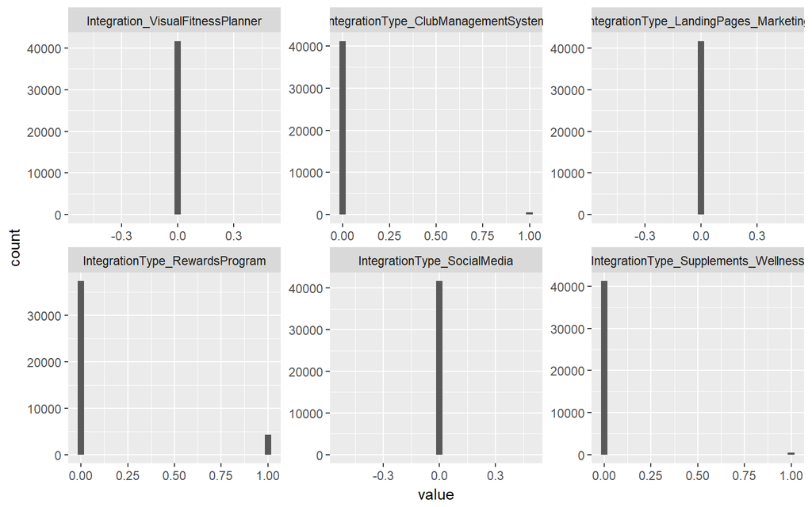

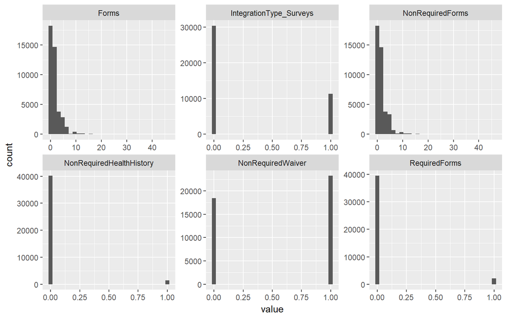

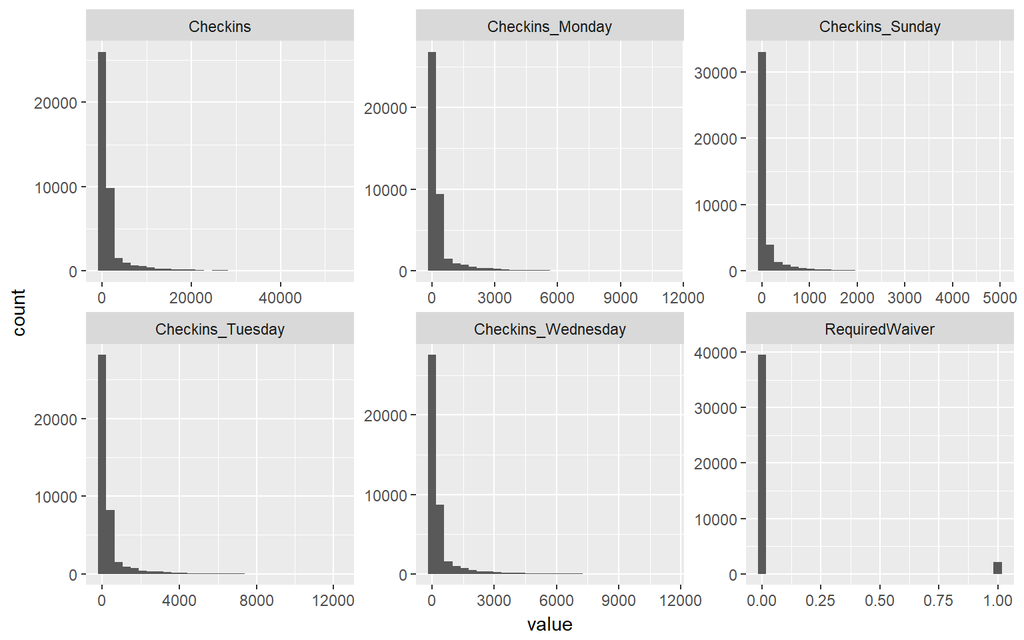

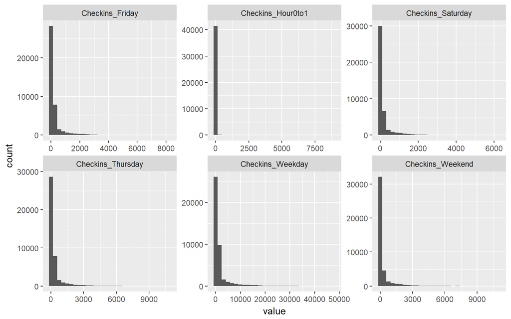

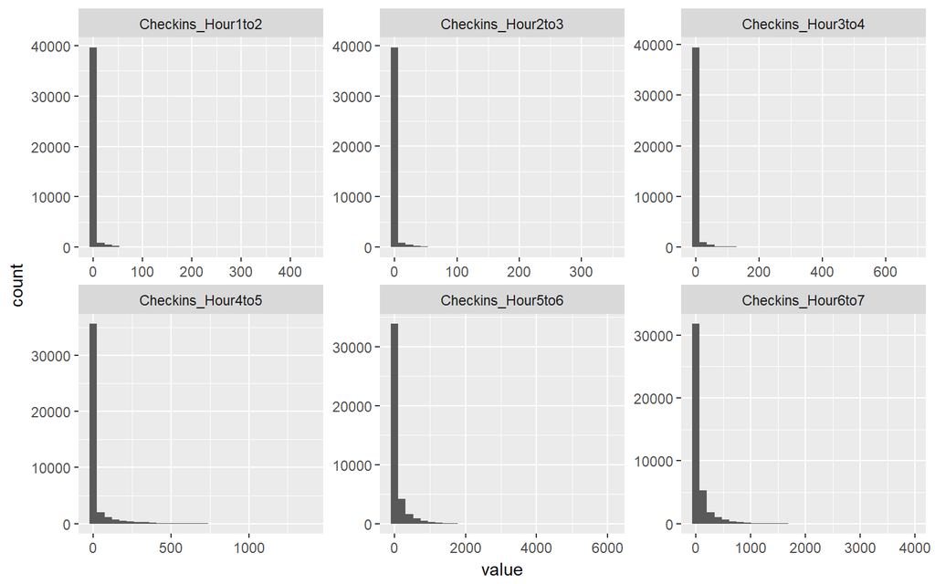

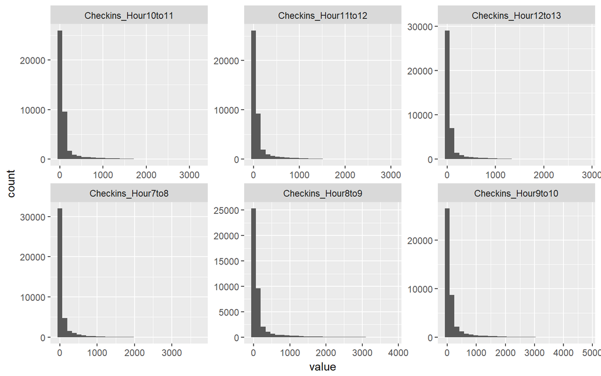

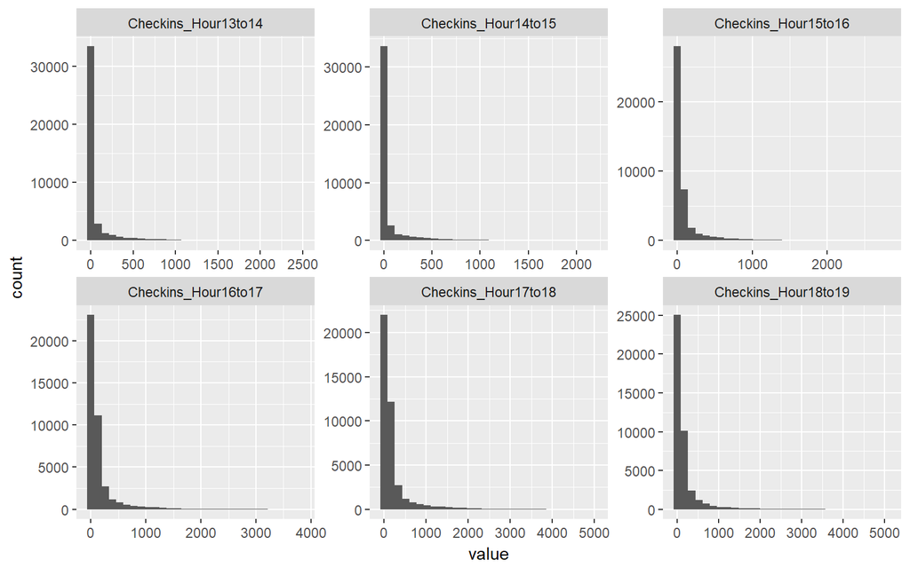

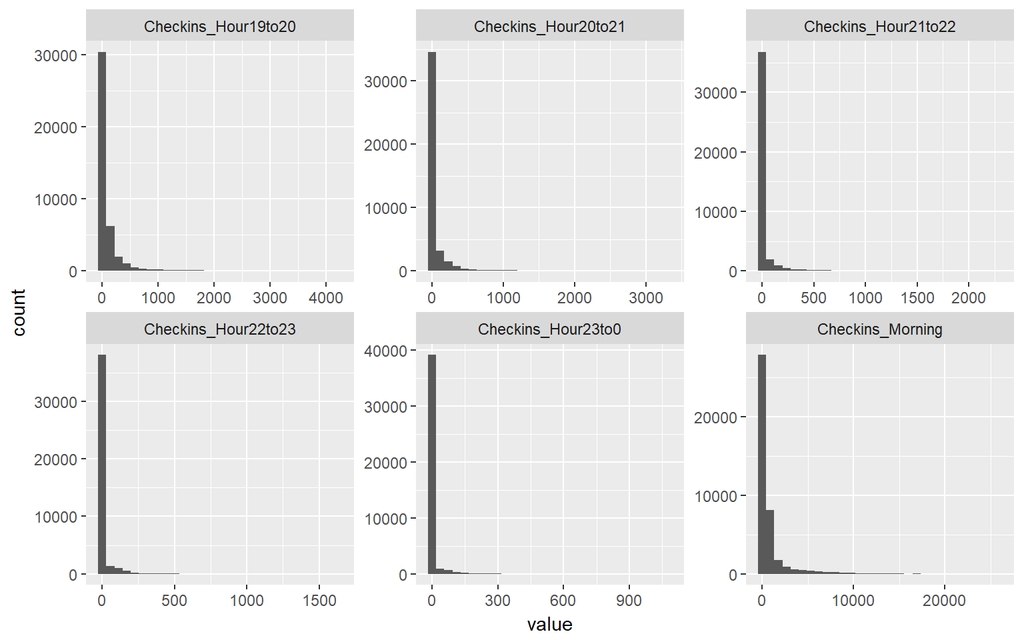

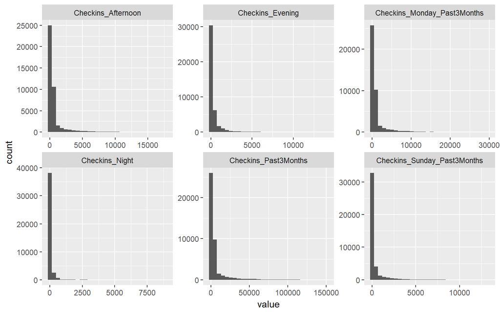

[7 more figures not shown]

```r
library(purrr)
library(tidyr)

cntNumNames <- length(select(select_if(stores,is.numeric), -StoreId))
#Make plots max 6 at a time - change if needed
maxPlot = 6
loopCnt <- cntNumNames %/% maxPlot
remainder <- cntNumNames %% maxPlot

myLoop_DF <- data.frame(x = seq(1, cntNumNames-remainder, by = maxPlot), y = seq(6, cntNumNames, by = maxPlot))
myLoopMax <- max(myLoop_DF)

for(i in 1:nrow(myLoop_DF)){
  myplot <- select(select_if(stores,is.numeric), -StoreId)[myLoop_DF[i,1]:myLoop_DF[i,2]]%>% gather() %>% ggplot(aes(value)) +
      facet_wrap(~ key, scales = "free") + geom_histogram() #+  geom_density()
  print(myplot)
}
```

Most of the plots above are not very interesting but there are a few that we might to revisit individually including `Amenities`, `Forms`, and `NonRequiredForms`.

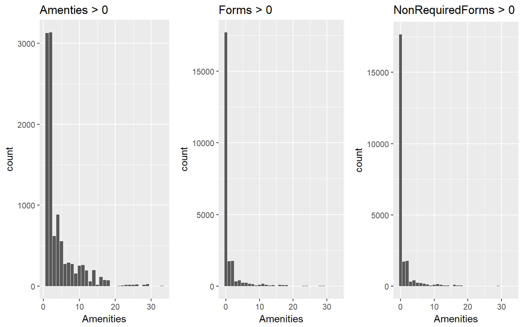

```r
p1 <- ggplot(filter(stores, Amenities > 0), aes(Amenities)) + geom_bar() + ggtitle("Amenties > 0")
p2 <- ggplot(filter(stores, Forms > 0), aes(Amenities)) + geom_bar() + ggtitle("Forms > 0")
p3 <- ggplot(filter(stores, NonRequiredForms > 0), aes(Amenities)) + geom_bar() + ggtitle("NonRequiredForms > 0")
grid.arrange(p1, p2, p3, ncol=3)
```

#### Variability

Evaluate how much variability there is in each numerical variable.

```r
#Col 1 -s StoreId, 20 is Status
myVariance <- as.data.frame(apply(stores[,-c(1,20)], 2, var))
myVariance <- tibble::rownames_to_column(myVariance)
names(myVariance)[2] <- "Variance"
myVariance <-  myVariance %>% mutate(Variance2 = ifelse(Variance == 0, "No", "Yes"))
table(myVariance$Variance2)
```

```
##
##  No Yes
##   7 110
```

Because 7 variables have no variance - all the values are the same, they can be removed from the working dataset. If there are no differences in a column, it is of no use in the development of an algorithm. The variables to be removed because there is no variance are:

```r
VarNames <- myVariance %>% filter(Variance > 0) %>% select(rowname)
zeroVarNames <- myVariance %>% filter(Variance == 0) %>% select(rowname)
stores <- stores %>% select(StoreId, Status, unlist(VarNames))
zeroVarNames
```

```
##                                  rowname
## 1                     Integration_FitBPO
## 2                 Integration_MotionSoft
## 3                  Integration_Paramount
## 4               Integration_ShareYourFit
## 5       Integration_VisualFitnessPlanner
## 6 IntegrationType_LandingPages_Marketing
## 7            IntegrationType_SocialMedia
```

#### Outlier Detection

In the working dataset, there is one variable, `TotalRevenue` that should be evaluated to identify any potential outlier. There are many way to visualize outliers. Boxplots are the most commonly used visualization.

```r
out2 <- ggplot(stores, aes(x = "", y = TotalRevenue)) + geom_boxplot(outlier.color="red", outlier.shape=8, outlier.size=4) +
  scale_y_continuous(labels = scales::dollar)
```

Here is a list of the highest 25 TotalRevenue records:

```r
tmpRev <- arrange(stores, desc(TotalRevenue)) %>% select(TotalRevenue)
tmpRev <- as.data.frame(head(scales::dollar(tmpRev$TotalRevenue), 25))
names(tmpRev) <- "Total_Revenue"
tmpRev
```

```
##    Total_Revenue
## 1     $9,155,556
## 2     $9,107,405
## 3     $8,044,618
## 4     $7,917,987
## 5     $7,695,146
## 6     $7,595,443
## 7     $7,553,951
## 8     $7,528,441
## 9     $7,150,346
## 10    $7,049,678
## 11    $6,973,129
## 12    $6,755,486
## 13    $6,742,283
## 14    $6,614,312
## 15    $6,604,380
## 16    $6,453,092
## 17    $6,298,918
## 18    $6,294,541
## 19    $6,193,235
## 20    $6,076,802
## 21    $5,976,849
## 22    $5,541,476
## 23    $5,444,348
## 24    $4,954,580
## 25    $4,687,897
```

```r
q <- quantile(stores$TotalRevenue)
stores$Qcut <- cut(stores$TotalRevenue, q)
levels(stores$Qcut) <- c("Q1", "Q2", "Q3", "Q4")
summary(stores$Qcut)[1:4]
```

```
##    Q1    Q2    Q3    Q4
## 10078 10415 10414 10415
```

It is curious, perhaps suspect, that the number of records in the 2nd, 3rd and 4th quartiles are the same. **This too needs to be evaluated.**

#### Duplicates

```r
# Duplicate Records
cat("The number of duplicated rows is", nrow(stores) - nrow(unique(stores)))
```

```
## The number of duplicated rows is 0
```

```r
# if(nrow(stores) - nrow(unique(stores)) > 0){
#   head(stores[duplicated(stores),])
#   stores <- stores[!duplicated(stores),]
# }
```

#### Data Overview

The working dataset has been initially scrubbed and evaluated. Take time to review and learn about the data.

The plots below illustrate how often many of the ClubReady configuration options are turned on.

First examine the variable names that start with `Integration`.

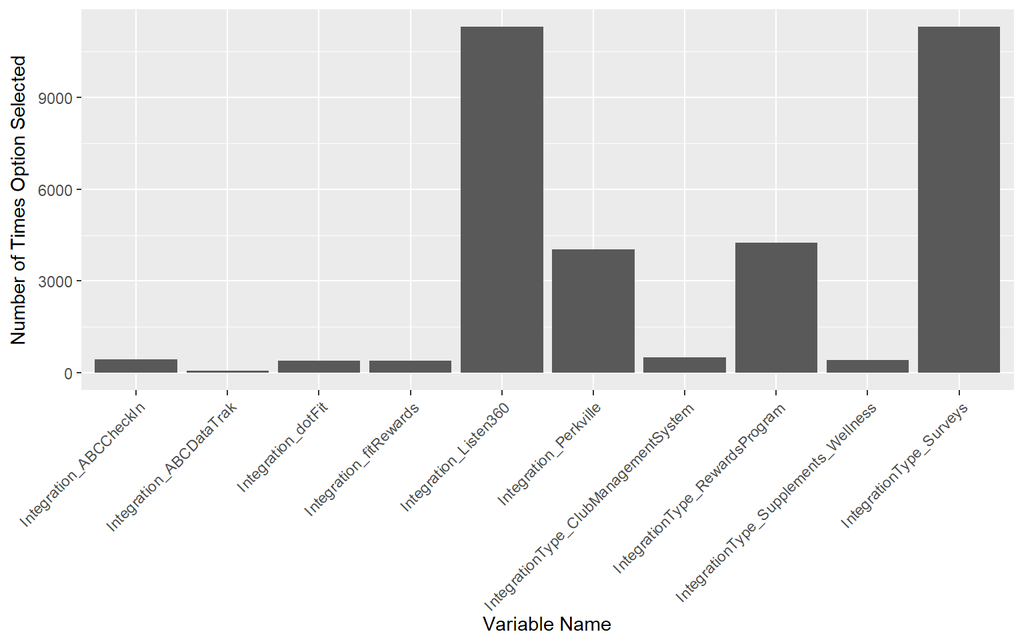

```r
myColTotal <- as.data.frame(colSums(Filter(is.numeric, stores)))
myColTotal <- tibble::rownames_to_column(myColTotal)
names(myColTotal)[1] <- "Variable_Name"
names(myColTotal)[2] <- "Sum_of_Variable"
myColTotal <- filter(myColTotal, !Variable_Name %in% c("StoreId", "TotalRevenue", "Amenities"))
myColTotal$Variable_Name <- as.factor(myColTotal$Variable_Name)
myColTotal <- myColTotal %>% arrange(desc(Sum_of_Variable))

ggplot(myColTotal %>% filter(Variable_Name %like% "Integration"), aes(x=Variable_Name, y=Sum_of_Variable)) +
  geom_bar(stat = "identity") + theme(axis.text.x = element_text(angle = 45, hjust = 1)) +
  xlab("Variable Name") + ylab("Number of Times Option Selected")
```

Below we find that most checkins occur between 8-11AM and 4-7PM local time. (Need to confirm)

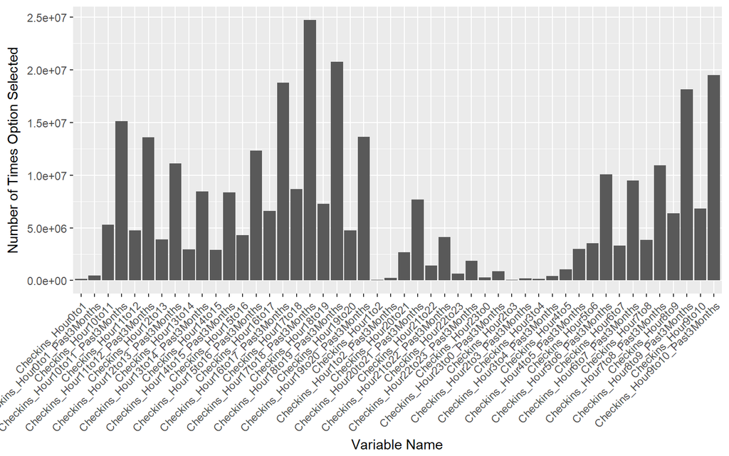

```r
ggplot(myColTotal %>% filter(Variable_Name %like% "Checkins_H" ), aes(x=Variable_Name, y=Sum_of_Variable)) +
  geom_bar(stat = "identity") + theme(axis.text.x = element_text(angle = 45, hjust = 1)) +
  xlab("Variable Name") + ylab("Number of Times Option Selected")
```

Lastly, Monday, Tuesday and Wednesday have the most checkins during the week.

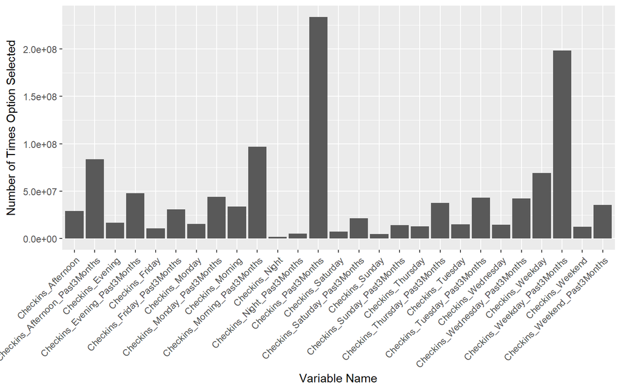

```r
ggplot(myColTotal %>% filter(!Variable_Name %like% "Checkins_H", Variable_Name %like% "Checkins_"),
       aes(x=Variable_Name, y=Sum_of_Variable)) +
  geom_bar(stat = "identity") + theme(axis.text.x = element_text(angle = 45, hjust = 1)) +
  xlab("Variable Name") + ylab("Number of Times Option Selected")
```

### Data Glimpse

```r
glimpse(stores)
```

```
## Observations: 41,659
## Variables: 113
## $ StoreId                              <int> 60, 105, 419, 206, 206, 3...
## $ Status                               <fctr> Active, Active, Inactive...
## $ IsChurn                              <int> 0, 1, 0, 0, 1, 0, 0, 0, 0...
## $ IsChurn_2Months                      <int> 0, 1, 0, 1, 1, 0, 0, 0, 0...
## $ IsChurn_3Months                      <int> 0, 1, 0, 1, 1, 0, 0, 0, 0...
## $ IsChurn_6Months                      <int> 0, 1, 1, 1, 1, 1, 0, 0, 1...
## $ SMSEnabled                           <int> 1, 1, 1, 1, 1, 1, 1, 1, 1...
## $ StoreAgeMonths                       <int> 92, 95, 76, 75, 77, 75, 8...
## $ Amenities                            <int> 0, 2, 0, 0, 0, 0, 0, 0, 0...
## $ Integration_ABCCheckIn               <int> 0, 0, 0, 0, 0, 0, 0, 0, 0...
## $ Integration_ABCDataTrak              <int> 0, 0, 0, 0, 0, 0, 0, 0, 0...
## $ Integration_dotFit                   <int> 0, 0, 0, 0, 0, 0, 0, 0, 0...
## $ Integration_fitRewards               <int> 0, 0, 0, 0, 0, 0, 0, 0, 0...
```

[output cut: 100 more lines]

#### Data Consolidation

#### Variable Selection

### Present Findings

## Risks and Assumptions

## Classes & Services

### Get Data

```r
#Get Data
Classes_Services <- read_csv("C:/Users/cweaver/Downloads/Classes_Services.csv",
                   col_types = cols(AvailablePIF = col_integer(),
                      ByPerson = col_integer(), CanSeeInstructor = col_integer(),
                      CancellationHrs = col_integer(),
                      ClassMins = col_integer(), CustSelfBook = col_integer(),
                      Disabled = col_integer(), EmailReminders = col_integer(),
                      HalfHour = col_integer(), MultipleInstructors = col_integer(),
                      MustHaveCredit = col_integer(), MustPreBook = col_integer(),
                      NumPerClass = col_integer(), OnTheHour = col_integer(),
                      QuarterPast = col_integer(), QuarterTill = col_integer(),
                      RescheduleDeadline = col_integer(),
                      RuleCustomers = col_integer(), RuleFrontDesk = col_integer(),
                      SMSReminders = col_integer(), ServicesId = col_integer(),
                      ShowPublic = col_integer(), StandardPrice = col_integer()),
                   na = "NA")

myData <- Classes_Services
rm(Classes_Services)
```

```r
glimpse(myData)
```

```
## Observations: 34,055
## Variables: 28
## $ Type                  <chr> "Class", "Class", "Class", "Class", "Cla...
## $ ClassId               <int> 2, 3, 33, 36, 37, 39, 41, 43, 44, 48, 51...
## $ ServicesId            <int> NA, NA, NA, NA, NA, NA, NA, NA, NA, NA, ...
## $ StoreId               <int> 1, 1, 11, 17, 20, 20, 20, 20, 20, 24, 20...
## $ Disabled              <int> NA, NA, NA, NA, 1, 1, 1, NA, NA, NA, NA,...
## $ MustPreBook           <int> 1, 1, 1, 1, 1, 1, 1, 1, 1, 1, NA, 1, 1, ...
## $ CustSelfBook          <int> 1, 1, 1, 1, 1, 1, 1, 1, 1, 1, NA, 1, 1, ...
## $ MustHaveCredit        <int> NA, NA, NA, NA, NA, NA, NA, NA, NA, NA, ...
## $ ClassMins             <int> 45, 60, 45, 120, 60, 60, 60, 30, 30, 60,...
## $ NumPerClass           <int> 6, 10, 9, 200, 10, 12, 40, 2, 4, 24, NA,...
## $ StandardPrice         <int> 0, 15, NA, NA, NA, NA, NA, NA, 25, 10, 1...
## $ MultipleInstructors   <int> 1, NA, NA, NA, NA, NA, NA, NA, NA, NA, N...
## $ AvailablePIF          <int> NA, 1, 1, 1, 1, 1, 1, 1, 1, 1, 1, 1, 1, ...
## $ EmailReminders        <int> 1, 1, NA, NA, NA, NA, NA, NA, NA, NA, NA...
## $ SMSReminders          <int> NA, NA, NA, NA, NA, NA, NA, NA, NA, NA, ...
## $ CanSeeInstructor      <int> 1, 1, 1, 1, 1, 1, 1, 1, 1, 1, 1, 1, 1, 1...
## $ ShowPublic            <int> NA, 1, 1, 1, 1, 1, 1, 1, 1, 1, 1, 1, 1, ...
## $ CanDirectlyBookPublic <int> 0, 0, 0, 0, 0, 0, 0, 0, 0, 0, 0, 0, 0, 0...
## $ AllowWaitList         <int> 0, 0, 0, 0, 0, 0, 0, 0, 0, 0, 0, 1, 0, 0...
## $ ByPerson              <int> NA, NA, NA, NA, NA, NA, NA, NA, NA, NA, ...
## $ OnTheHour             <int> NA, NA, NA, NA, NA, NA, NA, NA, NA, NA, ...
## $ QuarterPast           <int> NA, NA, NA, NA, NA, NA, NA, NA, NA, NA, ...
## $ HalfHour              <int> NA, NA, NA, NA, NA, NA, NA, NA, NA, NA, ...
## $ QuarterTill           <int> NA, NA, NA, NA, NA, NA, NA, NA, NA, NA, ...
## $ RuleFrontDesk         <int> NA, NA, NA, NA, NA, NA, NA, NA, NA, NA, ...
## $ RuleCustomers         <int> NA, NA, NA, NA, NA, NA, NA, NA, NA, NA, ...
## $ CancellationHrs       <int> 12, 12, 24, 48, 24, 24, 24, 24, 24, 24, ...
## $ RescheduleDeadline    <int> 12, 12, 24, 48, 12, 12, 12, 12, 12, 24, ...
```

### Remove NA

Just as we experienced before, must remove the `NAs` with 0:

```r
myData <- myData %>%  mutate_if(is.integer, funs(replace(., is.na(.), 0)))
myData <- myData %>%  mutate_if(is.double, as.integer)
glimpse(myData)
```

```
## Observations: 34,055
## Variables: 28
## $ Type                  <chr> "Class", "Class", "Class", "Class", "Cla...
## $ ClassId               <int> 2, 3, 33, 36, 37, 39, 41, 43, 44, 48, 51...
## $ ServicesId            <int> 0, 0, 0, 0, 0, 0, 0, 0, 0, 0, 0, 0, 0, 0...
## $ StoreId               <int> 1, 1, 11, 17, 20, 20, 20, 20, 20, 24, 20...
## $ Disabled              <int> 0, 0, 0, 0, 1, 1, 1, 0, 0, 0, 0, 0, 1, 0...
## $ MustPreBook           <int> 1, 1, 1, 1, 1, 1, 1, 1, 1, 1, 0, 1, 1, 1...
## $ CustSelfBook          <int> 1, 1, 1, 1, 1, 1, 1, 1, 1, 1, 0, 1, 1, 1...
## $ MustHaveCredit        <int> 0, 0, 0, 0, 0, 0, 0, 0, 0, 0, 0, 0, 0, 0...
## $ ClassMins             <int> 45, 60, 45, 120, 60, 60, 60, 30, 30, 60,...
## $ NumPerClass           <int> 6, 10, 9, 200, 10, 12, 40, 2, 4, 24, 0, ...
## $ StandardPrice         <int> 0, 15, 0, 0, 0, 0, 0, 0, 25, 10, 150, 0,...
## $ MultipleInstructors   <int> 1, 0, 0, 0, 0, 0, 0, 0, 0, 0, 0, 1, 0, 1...
## $ AvailablePIF          <int> 0, 1, 1, 1, 1, 1, 1, 1, 1, 1, 1, 1, 1, 1...
## $ EmailReminders        <int> 1, 1, 0, 0, 0, 0, 0, 0, 0, 0, 0, 1, 0, 0...
## $ SMSReminders          <int> 0, 0, 0, 0, 0, 0, 0, 0, 0, 0, 0, 0, 0, 0...
## $ CanSeeInstructor      <int> 1, 1, 1, 1, 1, 1, 1, 1, 1, 1, 1, 1, 1, 1...
## $ ShowPublic            <int> 0, 1, 1, 1, 1, 1, 1, 1, 1, 1, 1, 1, 1, 1...
## $ CanDirectlyBookPublic <int> 0, 0, 0, 0, 0, 0, 0, 0, 0, 0, 0, 0, 0, 0...
## $ AllowWaitList         <int> 0, 0, 0, 0, 0, 0, 0, 0, 0, 0, 0, 1, 0, 0...
## $ ByPerson              <int> 0, 0, 0, 0, 0, 0, 0, 0, 0, 0, 0, 0, 0, 0...
## $ OnTheHour             <int> 0, 0, 0, 0, 0, 0, 0, 0, 0, 0, 0, 0, 0, 0...
## $ QuarterPast           <int> 0, 0, 0, 0, 0, 0, 0, 0, 0, 0, 0, 0, 0, 0...
## $ HalfHour              <int> 0, 0, 0, 0, 0, 0, 0, 0, 0, 0, 0, 0, 0, 0...
## $ QuarterTill           <int> 0, 0, 0, 0, 0, 0, 0, 0, 0, 0, 0, 0, 0, 0...
## $ RuleFrontDesk         <int> 0, 0, 0, 0, 0, 0, 0, 0, 0, 0, 0, 0, 0, 0...
## $ RuleCustomers         <int> 0, 0, 0, 0, 0, 0, 0, 0, 0, 0, 0, 0, 0, 0...
## $ CancellationHrs       <int> 12, 12, 24, 48, 24, 24, 24, 24, 24, 24, ...
## $ RescheduleDeadline    <int> 12, 12, 24, 48, 12, 12, 12, 12, 12, 24, ...
```

That looks much better!

### Character to Factors

Change the variable `Type` from a character to a factor.

```r
myData <- myData %>% mutate_if(is.character, as.factor)
class(myData$Type)
```

```
## [1] "factor"
```

### Explore Factors

```r
charSummary(myData)
```

```
##          n miss miss% unique           top5levels:count
## Type 34055    0     0      2 Class:17465, Service:16590
```

```r
myData_factor <- myData %>% select_if(is.factor)
#myData_num <- myData %>% select_if(is.numeric)

for(i in 1:length(myData_factor)){
  print(names(myData_factor[i]))
  print(table(myData_factor[i]))
}
```

```
## [1] "Type"
##
##   Class Service
##   17465   16590
```

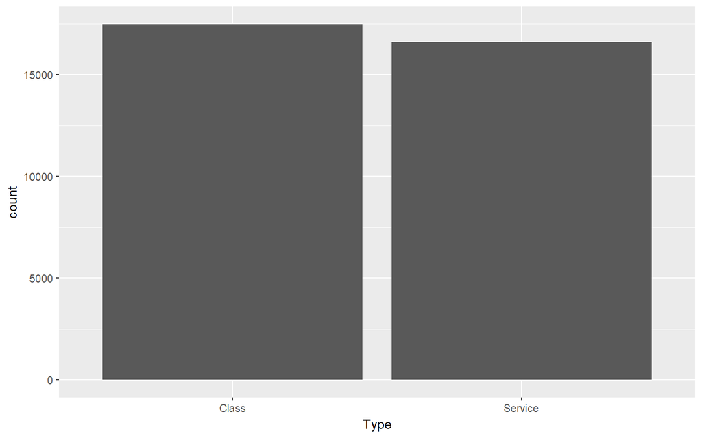

```r
for(i in 1:length(myData_factor)){
  print(ggplot(myData_factor, aes_string(names(myData_factor[i]))) + geom_bar())
}
```

**Uncertain how to define Class and Service - check with ClubReady**

### Numerical Data

```r
myNumSum <- numSummary(myData)[, c(1,7,8,16,17)]
myNumSum <- tibble::rownames_to_column(myNumSum)
names(myNumSum)[5] <- "missPCT"
names(myNumSum)[1] <- "Variable_Name"
myNumSum <- arrange(myNumSum, desc(missPCT))
head(myNumSum, 20)
```

```
##            Variable_Name     n nunique nzeros missPCT miss%
## 1                ClassId 34055   17466  16590       0     0
## 2             ServicesId 34055   11109  17465       0     0
## 3                StoreId 34055    3142      0       0     0
## 4               Disabled 34055       2  27661       0     0
## 5            MustPreBook 34055       2  22355       0     0
## 6           CustSelfBook 34055       2  17846       0     0
## 7         MustHaveCredit 34055       2  25805       0     0
## 8              ClassMins 34055      35   1385       0     0
## 9            NumPerClass 34055      75  22266       0     0
## 10         StandardPrice 34055     193  19681       0     0
## 11   MultipleInstructors 34055       2  26495       0     0
## 12          AvailablePIF 34055       2  24489       0     0
## 13        EmailReminders 34055       2  24428       0     0
## 14          SMSReminders 34055       2  32101       0     0
## 15      CanSeeInstructor 34055       2  23596       0     0
## 16            ShowPublic 34055       2  18127       0     0
## 17 CanDirectlyBookPublic 34055       2  33340       0     0
## 18         AllowWaitList 34055       2  31613       0     0
## 19              ByPerson 34055       2  17466       0     0
## 20             OnTheHour 34055       2  17561       0     0
```

Good, no missing data!

#### Variances

```r
myVariance <- as.data.frame(apply(myData[,-c(1)], 2, var))
myVariance <- tibble::rownames_to_column(myVariance)
names(myVariance)[2] <- "Variance"
myVariance <-  myVariance %>% mutate(Variance2 = ifelse(Variance == 0, "No", "Yes"))
table(myVariance$Variance2)
```

```
##
## Yes
##  27
```

All the variables have a variance > 0.

```r
if(table(myVariance$Variance2)[1] > 0){
  filter(myVariance, Variance2 == "No")
  VarNames <- myVariance %>% filter(Variance > 0) %>% select(rowname)
  myData <- myData %>% select(StoreId, unlist(VarNames))
}
```

#### Duplicate Records

```r
myData[duplicated(myData),]
```

```
## # A tibble: 12 x 27
##    StoreId ClassId ServicesId Disabled MustPreBook CustSelfBook
##      <int>   <int>      <int>    <int>       <int>        <int>
##  1    1507       0       6563        0           0            0
##  2    2785       0      18588        0           0            0
##  3    3167       0      18710        0           0            1
##  4    3167       0      18710        0           0            1
##  5    3950       0      20519        0           0            0
##  6    4096       0      20804        0           0            0
##  7    4097       0      20808        0           0            0
##  8    4098       0      20812        0           0            0
##  9    4099       0      20816        0           0            0
## 10    4010       0      23251        0           0            0
## 11    4127       0      24098        0           0            0
## 12    5897       0      24235        0           0            0
## # ... with 21 more variables: MustHaveCredit <int>, ClassMins <int>,
## #   NumPerClass <int>, StandardPrice <int>, MultipleInstructors <int>,
## #   AvailablePIF <int>, EmailReminders <int>, SMSReminders <int>,
## #   CanSeeInstructor <int>, ShowPublic <int>, CanDirectlyBookPublic <int>,
## #   AllowWaitList <int>, ByPerson <int>, OnTheHour <int>,
## #   QuarterPast <int>, HalfHour <int>, QuarterTill <int>,
## #   RuleFrontDesk <int>, RuleCustomers <int>, CancellationHrs <int>,
## #   RescheduleDeadline <int>
```

> Ask ClubReady if these should be removed

```r
if(nrow(myData) - nrow(unique(myData)) > 0){
  head(myData[duplicated(myData),])
  myData <- myData[!duplicated(myData),]
}
```

### Data Glimpse

```r
glimpse(myData)
```

[output not shown]

## Users

### Get Data

```r
Users <- read_csv("C:/Users/cweaver/Downloads/Users.csv", col_types = cols(StoreId = col_integer()), progress = FALSE)
myData <- Users
rm(Users)
```

```r
glimpse(myData)
```

```
## Observations: 17,516,305
## Variables: 48
## $ UserId                     <int> 1, 2, 3, 7, 8, 1059, 1169, 1172, 11...
## $ StoreId                    <int> NA, NA, 0, 0, NA, 1, 1, 1, 1, 1, 1,...
## $ CheckInCredentialsModified <int> 0, 1, 1, 1, 1, 0, 0, 0, 0, 0, 0, 0,...
## $ Gender                     <chr> "NULL", "NULL", "M", "M", "NULL", "...
## $ UserType                   <chr> "CrStaff", "CrStaff", "CrStaff", "D...
## $ Amenities                  <int> 0, 0, 0, 0, 0, 0, 0, 0, 0, 0, 0, 0,...
## $ Tags                       <int> 0, 0, 0, 0, 0, 0, 0, 0, 0, 0, 0, 0,...
## $ Checkins                   <int> 0, 0, 0, 0, 0, 0, 1, 0, 0, 9, 3, 1,...
## $ Checkins_Sunday            <int> 0, 0, 0, 0, 0, 0, 0, 0, 0, 1, 1, 0,...
## $ Checkins_Monday            <int> 0, 0, 0, 0, 0, 0, 0, 0, 0, 2, 0, 1,...
## $ Checkins_Tuesday           <int> 0, 0, 0, 0, 0, 0, 0, 0, 0, 0, 1, 0,...
## $ Checkins_Wednesday         <int> 0, 0, 0, 0, 0, 0, 0, 0, 0, 0, 1, 0,...
## $ Checkins_Thursday          <int> 0, 0, 0, 0, 0, 0, 1, 0, 0, 5, 0, 0,...
```

[output cut: 35 more lines]

### Remove NA

There do not appear to be as many `NAs` as we have seen before. This time they appear prevalent in the `StoreId` variable. Also note `NULL` in the `Gender` field.

```r
myData <- myData %>%  mutate_if(is.integer, funs(replace(., is.na(.), 0)))#changes int to dbl
myData[,-41] <- myData %>%  mutate_if(is.double, as.integer)#return to int
glimpse(myData$StoreId)
```

```
##  int [1:17516305] 0 0 0 0 0 1 1 1 1 1 ...
```

`StoreId` looks better now.

### Character to Factors

`Gender` and `UserType` are character variables. Change them to factors.

```r
myData <- myData %>% mutate_if(is.character, as.factor)
charSummary(myData)
```

```
##                 n miss    miss% unique
## Gender   17516304    1 5.71e-06     20
## UserType 17516305    0 0.00e+00     13
##                                                                                                            top5levels:count
## Gender                                                     F:6181600, M:5638707, NULL:2834500, Female:1527379, Male:1321975
## UserType ClubClient:15676776, DeletedClubClient:1645260, ClubClientTemporary:63819, DeletedClubAdmin:62840, ClubAdmin:55389
```

```r
myData_factor <- myData %>% select_if(is.factor)
```

Note `Gender` appears to have many missing values. These will be managed a bit later

#### Tables for the Factors

Examine the factors in the working dataset.

```r
for(i in 1:length(myData_factor)){
  print(names(myData_factor[i]))
  print(table(myData_factor[i]))
}
```

```
## [1] "Gender"
##
##         "         1     Erkek         f         F    female    Female
##         1         6         2      2326   6181600      3700   1527379
##         g     Kadin         m         M      male      Male Masculino
##         1         1      2349   5638707      2734   1321975         1
##         n      NULL         p         u         U
##       133   2834500         1        39       849
## [1] "UserType"
##
##                 CAS           ClubAdmin          ClubClient
##                   5               55389            15676776
## ClubClientTemporary         ClubTrainer           CorpAdmin
##               63819                 823                3256
##             CrStaff    DeletedClubAdmin   DeletedClubClient
##                 165               62840             1645260
##  DeletedClubTrainer    DeletedCorpAdmin      DeletedCrStaff
##                2776                2263                 164
##      Duplicate User
##                2769
```

```r
rm(myData_factor)
```

There is much work to do on the `Gender` variable. Will also choose the appropriate `UserType` values for modeling.

#### User Factor - Gender

The values in `Gender` are varied. These will need to be collapsed into a couple of factor levels.

```r
myData %>% group_by(Gender) %>% summarize(Unique_Values = n()) %>% arrange(desc(Unique_Values))
```

```
## # A tibble: 20 x 2
##       Gender Unique_Values
##       <fctr>         <int>
##  1         F       6181600
##  2         M       5638707
##  3      NULL       2834500
##  4    Female       1527379
##  5      Male       1321975
##  6    female          3700
##  7      male          2734
##  8         m          2349
##  9         f          2326
## 10         U           849
## 11         n           133
## 12         u            39
## 13         1             6
## 14     Erkek             2
## 15      "\""             1
## 16         g             1
## 17     Kadin             1
## 18 Masculino             1
## 19         p             1
## 20      <NA>             1
```

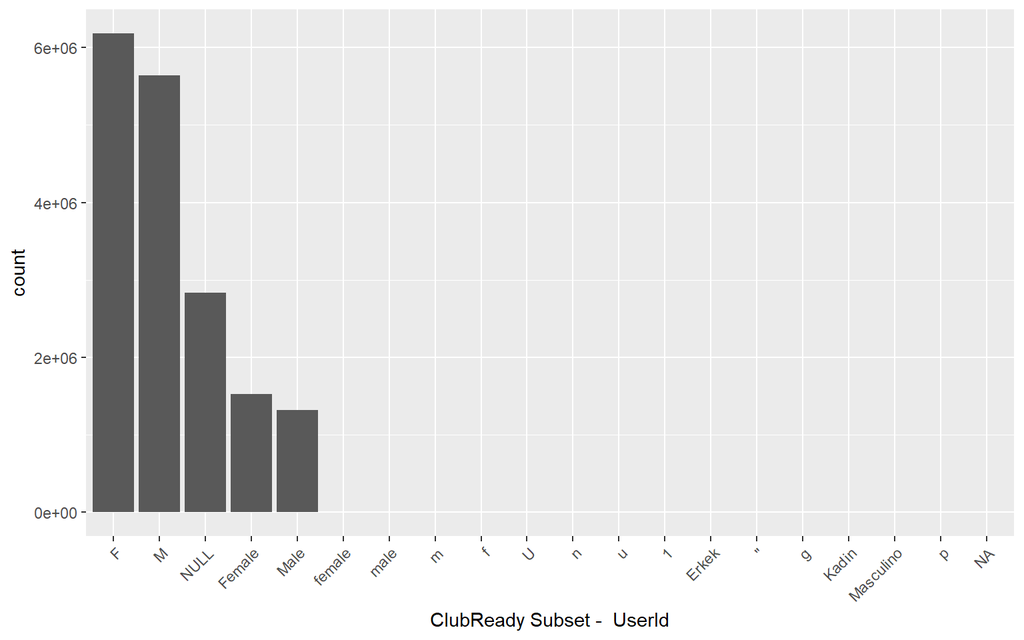

```r
ggplot(myData, aes(fct_infreq(Gender))) + geom_bar() + xlab(paste("ClubReady Subset - ", names(myData)[1])) +
  theme(axis.text.x = element_text(angle = 45, hjust = 1))
```

```r
levels(myData$Gender)[levels(myData$Gender) == "F"] <- "Female"
levels(myData$Gender)[levels(myData$Gender) == "female"] <- "Female"
levels(myData$Gender)[levels(myData$Gender) == "f"] <- "Female"

levels(myData$Gender)[levels(myData$Gender) == "M"] <- "Male"
levels(myData$Gender)[levels(myData$Gender) == "male"] <- "Male"
levels(myData$Gender)[levels(myData$Gender) == "m"] <- "Male"

myData %>% group_by(Gender) %>% summarize(Unique_Values = n()) %>% arrange(desc(Unique_Values))
```

```
## # A tibble: 14 x 2
##       Gender Unique_Values
##       <fctr>         <int>
##  1    Female       7715005
##  2      Male       6965765
##  3      NULL       2834500
##  4         U           849
##  5         n           133
##  6         u            39
##  7         1             6
##  8     Erkek             2
##  9      "\""             1
## 10         g             1
## 11     Kadin             1
## 12 Masculino             1
## 13         p             1
## 14      <NA>             1
```

This looks better but there are still suspect values. We will remove:

- All the `Gender` value counts that are small will be removed. This affects everything from `U` and below in the table above.
- It is reasonable to assume `Gender` is an informative variable in churn modeling. Valorem will initially remove the `NULL` values from `Gender`. **Note to Brad** **BL: Why would we throw out the entire record because Gender is inappropriately defined? It’s a far safer option to use an “Unknown” placeholder. This is what I’ve done in the SQL.**

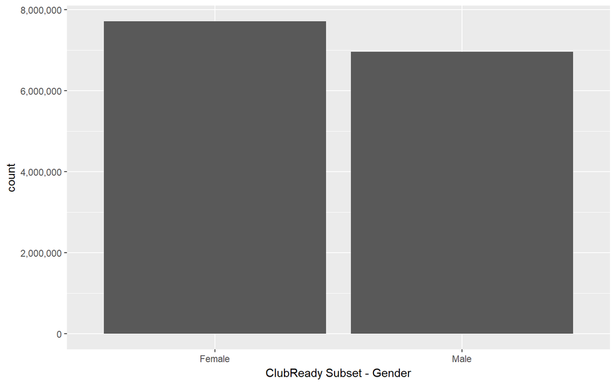

```r
myData <- filter(myData, Gender == "Female" | Gender == "Male")
myData$Gender <- factor(myData$Gender)

ggplot(myData, aes(fct_infreq(Gender))) + geom_bar() + xlab("ClubReady Subset - Gender") +
  scale_y_continuous(labels = scales::comma)
```

#### User Factor - UserType

```r
myData %>% group_by(UserType) %>% summarize(Unique_Values = n()) %>% arrange(desc(Unique_Values))
```

```
## # A tibble: 13 x 2
##               UserType Unique_Values
##                 <fctr>         <int>
##  1          ClubClient      13111028
##  2   DeletedClubClient       1425029
##  3    DeletedClubAdmin         56073
##  4           ClubAdmin         44420
##  5 ClubClientTemporary         32757
##  6           CorpAdmin          3221
##  7  DeletedClubTrainer          2773
##  8    DeletedCorpAdmin          2250
##  9      Duplicate User          2210
## 10         ClubTrainer           819
## 11             CrStaff           106
## 12      DeletedCrStaff            79
## 13                 CAS             5
```

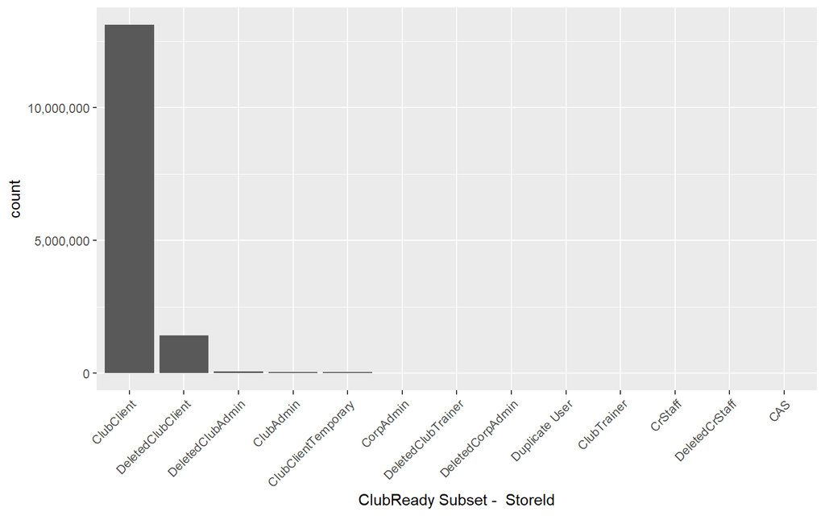

```r
ggplot(myData, aes(fct_infreq(UserType))) + geom_bar() + xlab(paste("ClubReady Subset - ", names(myData)[2])) +
  theme(axis.text.x = element_text(angle = 45, hjust = 1)) + scale_y_continuous(labels = scales::comma)
```

ClubReady confirmed Valorem to use:

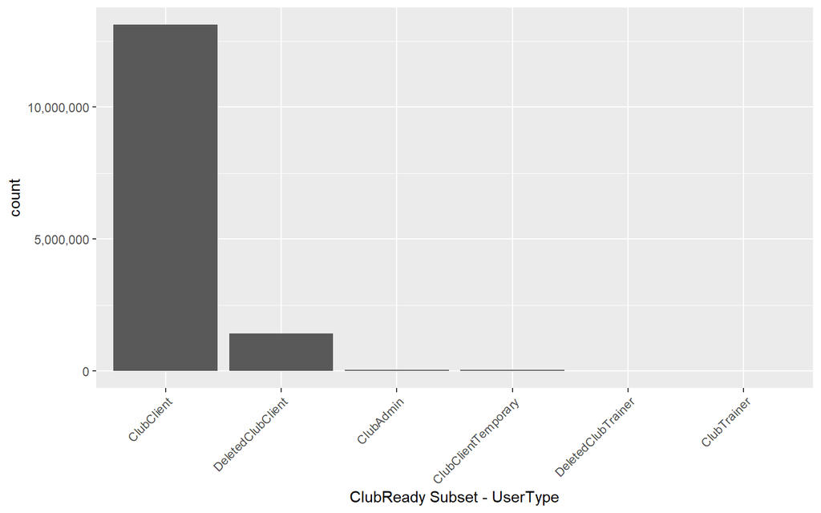

```r
myData <- filter(myData, UserType == 'ClubClient' | UserType == 'DeletedClubClient' | UserType == 'ClubAdmin' | UserType == 'ClubTrainer' | UserType == 'DeletedClubTrainer' | UserType == 'ClubClientTemporary')
myData$UserType <- factor(myData$UserType)

ggplot(myData, aes(fct_infreq(UserType))) + geom_bar() + xlab("ClubReady Subset - UserType") +
  theme(axis.text.x = element_text(angle = 45, hjust = 1)) + scale_y_continuous(labels = scales::comma)
```

Given the distribution above, Valorem may remove the infrequently used `UserType` values. **Note to Brad** **Please see above, these are removed as they are not members.**

### Numerical Data

> Because of the large number of `User` records, a random sample is selected in the code below.

```r
myNumSum <- numSummary(sample_frac(myData, .3))[, c(1,7,8,16,17)]
myNumSum <- tibble::rownames_to_column(myNumSum)
names(myNumSum)[5] <- "missPCT"
names(myNumSum)[1] <- "Variable_Name"
myNumSum <- arrange(myNumSum, desc(missPCT))
head(myNumSum, 20)
```

```
##                 Variable_Name       n nunique  nzeros missPCT miss%
## 1                      UserId 4385048 4385048       0       0     0
## 2                     StoreId 4385048    3868    2648       0     0
## 3  CheckInCredentialsModified 4385048       2  483581       0     0
## 4                   Amenities 4385048      37 4236083       0     0
## 5                        Tags 4385048       7 4363923       0     0
## 6                    Checkins 4385048    1957 3232051       0     0
## 7             Checkins_Sunday 4385048     392 3936647       0     0
## 8             Checkins_Monday 4385048     495 3510704       0     0
## 9            Checkins_Tuesday 4385048     490 3513171       0     0
## 10         Checkins_Wednesday 4385048     488 3515645       0     0
## 11          Checkins_Thursday 4385048     458 3545931       0     0
## 12            Checkins_Friday 4385048     459 3628376       0     0
## 13          Checkins_Saturday 4385048     400 3770727       0     0
## 14          Checkins_Hour0to1 4385048     522 4349999       0     0
## 15          Checkins_Hour1to2 4385048     131 4372669       0     0
## 16          Checkins_Hour2to3 4385048     139 4376345       0     0
## 17          Checkins_Hour3to4 4385048     228 4375247       0     0
## 18          Checkins_Hour4to5 4385048     506 4349306       0     0
## 19          Checkins_Hour5to6 4385048     767 4251145       0     0
## 20          Checkins_Hour6to7 4385048     654 4200908       0     0
```

No missing data is in the working dataset.

#### Variance

```r
#Do not include UserId, StoreId, Gender, UserType, TotalSpent
myVariance <- as.data.frame(apply(myData[,-c(1,2,4,5,41)], 2, var))
myVariance <- tibble::rownames_to_column(myVariance)
names(myVariance)[2] <- "Variance"
myVariance <-  myVariance %>% mutate(Variance2 = ifelse(Variance == 0, "No", "Yes"))
table(myVariance$Variance2)
```

```
##
##  No Yes
##   1  42
```

Because 1 variables have no variance - all the values are the same, they can be removed from the working dataset. If there are no differences in a column, it is of no use in the development of an algorithm. The variables to be removed because there is no variance are:

```r
if(table(myVariance$Variance2)[1] > 0){
  VarNames <- myVariance %>% filter(Variance > 0) %>% select(rowname)
  zeroVarNames <- myVariance %>% filter(Variance == 0) %>% select(rowname)
  myData <- myData %>% select(UserId, StoreId, Gender, TotalSpent,  unlist(VarNames))
  zeroVarNames
}
```

```
##          rowname
## 1 RequiredWaiver
```

#### Outlier Detection

In the working dataset, there is one variable, `TotalSpent` that should be evaluated to identify any potential outlier. There are many way to visualize outliers. While boxplots are the most commonly used visualization, because the number of records is large, plotting is not an optimal reporting option - it takes a long time to plot millions of records.

Comparing the opposite ends of `TotalSpent` produces interesting information:

```r
tmpRevDesc <- arrange(myData, desc(TotalSpent)) %>% select(TotalSpent)
tmpRevDesc <- tmpRevDesc[1:25,]
tmpRevDesc <- as.data.frame(scales::dollar(tmpRevDesc$TotalSpent))
names(tmpRevDesc) <- "Total_Spent"

tmpRevAsc <- arrange(myData, TotalSpent) %>% select(TotalSpent)
tmpRevAsc <- tmpRevAsc[1:25,]
tmpRevAsc <- as.data.frame(scales::dollar(tmpRevAsc$TotalSpent))
names(tmpRevAsc) <- "Total_Spent"

knitr::kable(list(tmpRevDesc, tmpRevAsc))
```

| Total_Spent |
| --- |
| $10,004,136 |
| $3,204,780 |
| $2,759,211 |
| $2,680,537 |
| $2,640,971 |
| $2,401,029 |
| $2,382,642 |
| $2,375,716 |
| $2,358,190 |
| $2,260,660 |
| $2,164,586 |
| $2,128,461 |
| $2,092,029 |
| $2,073,144 |
| $2,041,499 |
| $2,019,114 |
| $2,004,718 |
| $1,996,531 |
| $1,991,202 |
| $1,981,019 |
| $1,953,575 |
| $1,929,700 |
| $1,891,658 |
| $1,799,289 |
| $1,787,595 |

| Total_Spent |
| --- |
| $-638,972 |
| $-293,628 |
| $-42,475 |
| $-27,678 |
| $-18,986 |
| $-16,860 |
| $-16,254 |
| $-15,842 |
| $-14,992 |
| $-14,991 |
| $-14,542 |
| $-12,195 |
| $-10,793 |
| $-8,495 |
| $-7,579 |
| $-7,496 |
| $-6,207 |
| $-5,797 |
| $-4,245 |
| $-4,098 |
| $-4,098 |
| $-4,098 |
| $-3,995 |
| $-3,798 |
| $-3,398 |

#### Duplication

```r
cat("The number of duplicated rows is", nrow(myData) - nrow(unique(myData)))
```

```
## The number of duplicated rows is 0
```

```r
if((nrow(myData) - nrow(unique(myData)))>0) myData[duplicated(myData),]
```

```r
if(nrow(myData) - nrow(unique(myData)) > 0){
  head(myData[duplicated(myData),])
  myData <- myData[!duplicated(myData),]
}
```

Good news - no duplicate records.

### Data Glimpse

Here is what the resulting working dataset looks like. We are left with 14616826 records and 46.

```r
glimpse(myData)
```

```
## Observations: 14,616,826
## Variables: 46
## $ UserId                     <int> 1059, 1169, 1172, 1178, 1187, 1188,...
## $ StoreId                    <int> 1, 1, 1, 1, 1, 1, 1, 1, 1, 1, 1, 1,...
## $ Gender                     <fctr> Male, Male, Male, Female, Male, Ma...
## $ TotalSpent                 <dbl> 0, 0, 0, 0, 0, 0, 0, 0, 0, 0, 0, 0,...
## $ CheckInCredentialsModified <int> 0, 0, 0, 0, 0, 0, 0, 0, 0, 0, 0, 0,...
## $ Amenities                  <int> 0, 0, 0, 0, 0, 0, 0, 0, 0, 0, 0, 0,...
## $ Tags                       <int> 0, 0, 0, 0, 0, 0, 0, 0, 0, 0, 0, 0,...
## $ Checkins                   <int> 0, 1, 0, 0, 9, 3, 1, 0, 1, 0, 0, 0,...
## $ Checkins_Sunday            <int> 0, 0, 0, 0, 1, 1, 0, 0, 0, 0, 0, 0,...
## $ Checkins_Monday            <int> 0, 0, 0, 0, 2, 0, 1, 0, 0, 0, 0, 0,...
## $ Checkins_Tuesday           <int> 0, 0, 0, 0, 0, 1, 0, 0, 0, 0, 0, 0,...
## $ Checkins_Wednesday         <int> 0, 0, 0, 0, 0, 1, 0, 0, 1, 0, 0, 0,...
## $ Checkins_Thursday          <int> 0, 1, 0, 0, 5, 0, 0, 0, 0, 0, 0, 0,...
```

[output cut: 33 more lines]

# Initial Data Modeling

This section walks through the Initial Data Modeling phase to identify candidate algorithms to predict different churn models for ClubReady. The section is organized as follows:

- One of two CSV data files for modelling, stores.csv, is explored with detail in the first section
- In the following sections, the other data file (Users) is explored albeit with less explanatory content
- All of these sections roughly follow the same thought process:
  - Develop modeling data structure
  - Create modeling data file and import to Azure Machine Learning Studio
  - Perform Test/Training Data Split
  - Determine “Optimal” Initial Model

All of the SQL used to develop these datasets can be found in the [ML].[ChurnScripts] stored procedure within the [Reports] database.

## Stores

### Develop Modeling Data Structure

#### What is Churn?

During the On-Site Workshop, ClubReady provided a basic definition of “Store Churn”. If a Store recognizes at least an 80% drop in Revenue over the course of a single month, then that Store is considered to be Churned. We are leaving the possibility open of altering this percentage in later iterations.

With that definition, we then needed to answer “What is Revenue?” ClubReady provided the definition that Revenue is the total dollars invoiced to the Store by ClubReady. This information is available in the [PurchaseLog] table within the [ClubReady] database. Within this table, we utilize the [StoreId], [PaymentMade] and [PurchaseAmount] columns to determine when the store has “churned”.

As an added note, we also do not allow a single store to churn more than once within our time frame. For the purposes of this engagement, ClubReady agreed to a two-year time frame starting in November 2015 and ending in October 2017.

#### Dataset Granularity

The next important consideration is the “granularity” of the modelling dataset. Granularity defines what each row in the dataset represents. In general, the granularity of the modelling dataset should match the data **as it’s intended to be used in production.** During the On-Site Workshop, we discussed this with ClubReady. Their intention is to receive some type of notification that a store is likely to churn within the next few months. Therefore, we need a dataset where each row describes a single store for a single month and whether that store churned within that month or within the next few months. This allows ClubReady to run a monthly reporting or notification system that alerts them which stores are at risk of churning.

### Create Modeling Data File

Using the information from the On-Site Workshop combined with what we learned in the Exploratory Data Analysis phase, we are ready to create our modeling dataset. We identified the following subject areas within the ClubReady database:

- Store Info (Status, Age)
- SMS
- Amenities
- Integrations
- Forms
- Checkins
- Purchased Sessions
- Revenue
- Active Users
- Active Employees
- Classes
- Services

The goal is to create a monthly “snapshot” of each store showing information about that store at that point in time. However, not all of these subject areas can be queried historically. This means that we have no option but to take the data as it is today, assuming that it hasn’t changed over time. Obviously, this isn’t the case. However, this is an area for improvement in ClubReady’s system. The following subject areas do not track historic information:

- Store info (Status)
- SMS
- Amenities
- Integrations
- Forms
- Classes
- Services

This leaves the following subject areas with historic information:

- Store Info (Age)
- Checkins
- Purchased Sessions
- Revenue
- Active Users
- Active Employees

To empower our models using time intelligence, we also included metrics for these subject areas over the past three months. For instance, we have variables for [TotalRevenue_Past3Months] and [ActiveMembers_Past3Months].

We were able to combine all of this information into a single dataset. The queries to create the “Stores.csv” file can be found in the [ML].[ClubChurn] and [ML].[CompleteStoreData] stored procedures in the [Reports] database.

### Perform Test/Training Data Split

Once the data is imported into Azure Machine Learning Studio, we come to the next stage of the Initial Data Modeling phase, Test/Training Split. Just as with the “Modeling Data Structure” phase, our training and testing data should represent a **production use case** as closely as possible. In this instance, ClubReady wants to be able to identify whether a store is likely to churn in the next few months. Therefore, we want to test our model using the most recent information we can where we know whether the store will churn within the next few months.

In this instance, we chose to use three months as our timeframe. Since the last month in our dataset is October 2017, our testing month should be August 2017. The records for August 2017 will contain information about the month of August, as well as the previous two months for the “Past3Months” variables. These records will also contain a variable, [IsChurn_3Months], describing whether the store will churn in the next three months. This is what we are trying to predict.

In machine learning, it’s very important that the model be tested using data that was not used to train it. For instance, if a store churns in August 2017, then that will be reflected in the [IsChurn_3Months] variable for the months of June and July as well. To eliminate the possibility of testing our model with data it has already seen, we ended our training set at May 2017. Also, to ensure accuracy of our “Past 3 Month” variables, we do not want to use the first two months in our dataset. Therefore, we end up with the following training/testing split:

- Training Set 1
- Start Month: January 2016
- End Month: May 2017
- Testing Set 1
- Start Month: August 2017
- End Month: August 2017
- Variable to Predict: IsChurn_3Months

For additional testing, we can also move backwards any number of months to create new training/testing splits as follows:

- Training Set 2
- Start Month: January 2016
- End Month: April 2017
- Testing Set 2
- Start Month: July 2017
- End Month: July 2017
- Training Set 3
- Start Month: January 2016
- End Month: March 2017
- Testing Set 3
- Start Month: June 2017
- End Month: June 2017

### Determine “Optimal” Initial Model

The Initial Modeling phase has two goals. First, the goal is to determine how much of a “pattern” is easily accessible within the data. For instance, if the best model we can create in this phase falls substantially below what we would consider “reasonable”, then we may decide that we need more or different data to begin. We may also find that the pattern is strong enough to consider how much, if any, additional effort should be put into solving the issue at hand. Second, if sufficient pattern exists within the data available, then we can use the information we gain from this phase to point us towards the best way to improve the model using feature engineering or additional model optimization.

#### Selecting an Evaluation Metric

The selection of an evaluation metric is one of the most crucial aspects of the data modelling process. Recognizing that we are in a Binary Classification situation, we are limited to two main contenders, Accuracy/AUC and Precision/Recall. In general, Accuracy/AUC are acceptable when the two classes, “Churn” and “Not Churn” in this case, are approximately equally likely. However, in cases where one class is substantially more likely than another, Precision/Recall is the standard.

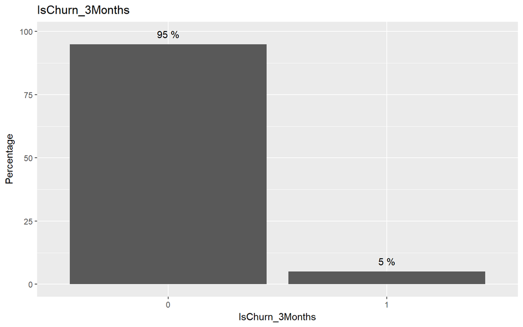

```r
finalstoredata <- read_csv("C:/Users/cweaver/Downloads/Stores_2017_12_11.csv", col_types = cols())

churn <- finalstoredata["IsChurn_3Months"] %>%
    group_by(IsChurn_3Months) %>%
    summarise(count=n()) %>%
    mutate(perc=count/sum(count))

ggplot(churn, aes(x = factor(IsChurn_3Months), y = perc*100)) + geom_bar(stat="identity") + ggtitle("IsChurn_3Months") + xlab("IsChurn_3Months") + ylab("Percentage") + geom_text(aes(x = factor(IsChurn_3Months), y = perc*100, label = paste(round(perc*100,0),"%")), nudge_y = 4)
```

**HOW DO I CENTER-ALIGN MY TITLE LIKE YOU DO ABOVE?**

Since the [IsChurn_3Months] variable is heavily imbalanced, we will go with Precision/Recall as our metric. In this context, Precision is the percentage of correct Churn predictions out of all Churn predictions. Conversely, Recall is the percentage of correct Churn predictions out of all actual Churn records. Basically, Recall tells us how many of the actual Churns we are predicting, while Precision tells us how many of our predictions are actually Churns. Both of these metrics tell different stories and are very important. So maximizing both of them would be ideal. Therefore, we will use an evaluation metric of Precision * Recall.

### The “Kitchen Sink” Approach

Given the size of the Stores dataset, we have the option of running through many models in a short timeframe. Because of this, we will utilize the “Kitchen Sink” approach. Azure Machine Learning Studio contains fifteen distinct Binary Classification algorithms. Fourteen of these can utilize a module called “Tune Model Hyperparameters”. This module will allow us to train and test multiple machine learning algorithms using different sets of hyperparameters. Therefore, if we pass our data through all fourteen possible modules, we can get a very good feeling for the patterns within the data. The process looks like this:

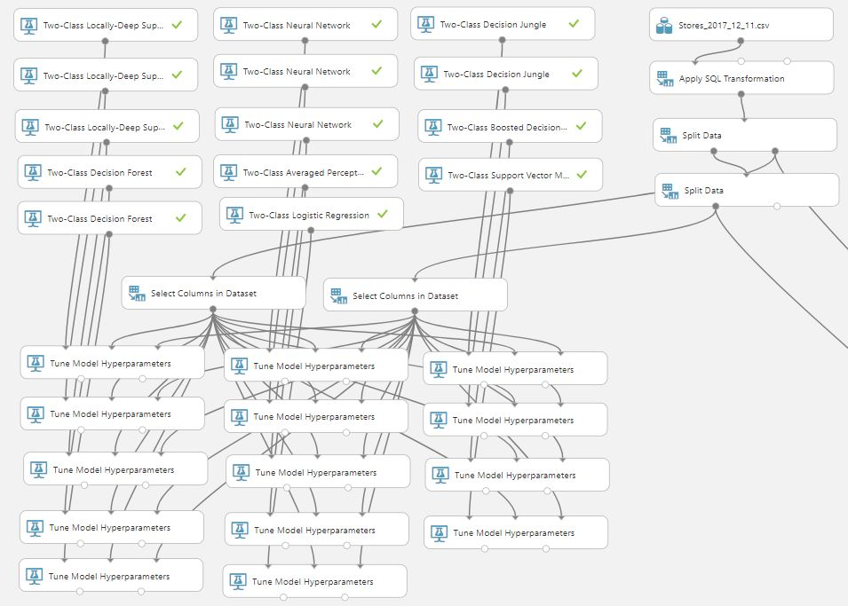

The full results of this process can be found in the “Store Churn Data Modelling Results.xlsx” file. Here are the top three models for predicting Store Churn:

| Model Family | Hyperparameters | Precision | Recall |
| --- | --- | --- | --- |
| Boosted Decision Tree | Leaves: 54 ~ Minimum Instances: 19 ~ Learning Rate: 0.336396 ~ Trees: 51 | 89.3% | 38.4% |
| Boosted Decision Tree | Leaves: 5 ~ Minimum Instances: 37 ~ Learning Rate: 0.030064 ~ Trees: 362 | 100.0% | 30.8% |
| Boosted Decision Tree | Leaves: 6 ~ Minimum Instances: 15 ~ Learning Rate: 0.356604 ~ Trees: 482 | 95.2% | 30.8% |

These results are extremely promising. While we can’t say for certain at this point, we now have evidence that there is a strong pattern within the data that we can use to predict when a Store is likely to churn.

## Users

### Develop Modeling Data Structure

#### What is Churn?

During the On-Site Workshop, ClubReady provided a basic definition of “User Churn”. If a User’s contract expires and isn’t renewed by the end of the next month, then that User has churned. This information is available in the [ContractPurchases] table within the [ClubReady] database. Within this table, we utilize the [UserId], [ActivationDateUTC], [AgreedDate] and [Cancelled] columns.

Just as with Store Churn, we do not allow a single user to churn more than once within our time frame.

#### Dataset Granularity

Given the similarity between User Churn and Store Churn, we were able to utilize similar logic to define the dataset for User Churn. The granularity of the User Churn data is per user, per month, for every month that the user has an active contract, plus an additional record for the month after their contract ends. This is the “Churn” month.

### Create Modeling Data File

Using the information from the On-Site Workshop combined with what we learned in the Exploratory Data Analysis phase, we are ready to create our modeling dataset. We identified the following subject areas within the ClubReady database:

- Store Churn Data
- User Info (Gender, Type, CheckinCredentialsModified)
- Amenities
- Tags
- Checkins
- Forms
- Purchased Sessions
- Spend

The goal is to create a monthly “snapshot” of each user showing information about that user at that point in time. However, not all of these subject areas can be queried historically. This means that we have no option but to take the data as it is today, assuming that it hasn’t changed over time. Obviously, this isn’t the case. However, this is an area for improvement in ClubReady’s system. The following subject areas do not track historic information:

- Store Churn Data (see previous section)
- User Info (Gender, Type, CreckinCredentialsModified)
- Amenities
- Tags
- Forms

This leaves the following subject areas with historic information:

- Store Churn Data (see previous section)
- Checkins
- Purchased Sessions
- Spend

To empower our models using time intelligence, we also included metrics for these subject areas over the past three months. For instance, we have variables for [TotalSpend_Past3Months] and [Checkins_Past3Months].

We were able to combine all of this information into a single dataset. The queries to create the “User.csv” file can be found in the [ML].[MemberChurn] and [ML].[CompleteUserData] stored procedures in the [Reports] database.

### Perform Test/Training Data Split

The logic for the test/training split is identical to that of “Store Churn”.

- Training Set 1
- Start Month: January 2016
- End Month: May 2017
- Testing Set 1
- Start Month: August 2017
- End Month: August 2017
- Variable to Predict: IsChurn_3Months

For additional testing, we can also move backwards any number of months to create new training/testing splits as follows:

- Training Set 2
- Start Month: January 2016
- End Month: April 2017
- Testing Set 2
- Start Month: July 2017
- End Month: July 2017
- Training Set 3
- Start Month: January 2016
- End Month: March 2017
- Testing Set 3
- Start Month: June 2017
- End Month: June 2017

### Determine “Optimal” Initial Model

#### Selecting an Evaluation Metric

A major difference between the Store and User data is the overall size of the data. The entire [FinalUserData] table takes up 24GB as a CSV. Therefore, it would be wise to sample the data down to a usable size. We created CSVs for randomly selected sets of 1M, 5M, 10M and 20M rows.

```r
finaluserdata <- read_csv("C:/Users/cweaver/Downloads/Users_1M_2017_12_12.csv", col_types = cols(
    Store_UserEmployeeRatio = col_double(),
    Store_UserEmployeeRatio_Last3Months = col_double(),
    Store_AverageMinsPerClass_Service = col_double(),
    Store_AveragePricePerClass_Service = col_double(),
    Store_AverageCancellationHrsPerClass_Service = col_double(),
    Store_AverageRescheduleDeadlinePerClass_Service = col_double(),
    Store_AverageMinsPerClass = col_double(),
    Store_AveragePricePerClass = col_double(),
    Store_AverageCancellationHrsPerClass = col_double(),
    Store_AverageRescheduleDeadlinePerClass = col_double(),
    Store_AverageMinsPerService = col_double(),
    Store_AveragePricePerService = col_double(),
    Store_AverageCancellationHrsPerService = col_double(),
    Store_AverageRescheduleDeadlinePerService = col_double())
    ,progress = FALSE
)
```

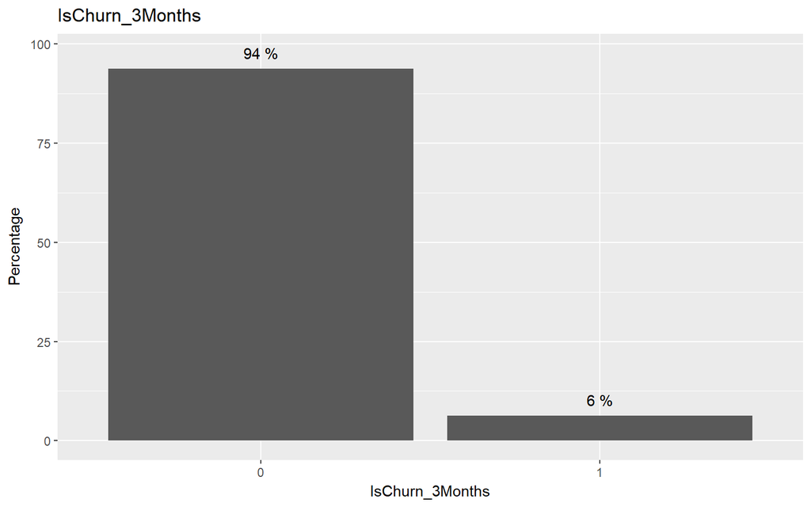

```r
churn <- finaluserdata["IsChurn_3Months"] %>% group_by(IsChurn_3Months) %>% summarise(count=n()) %>% mutate(perc=count/sum(count))

ggplot(churn, aes(x = factor(IsChurn_3Months), y = perc*100)) + geom_bar(stat="identity") + ggtitle("IsChurn_3Months") + xlab("IsChurn_3Months") + ylab("Percentage") + geom_text(aes(x = factor(IsChurn_3Months), y = perc*100, label = paste(round(perc*100,0),"%")), nudge_y = 4)
```

**HOW DO I CENTER-ALIGN MY TITLE LIKE YOU DO ABOVE?**

Using one of these files, we can easily see that Precision/Recall is going to be the optimal metric for this scenario as well. We have confirmed this result using the larger datasets as well.

### The “Kitchen Sink” Approach

The full results of this process can be found in the “User Churn Data Modelling Results.xlsx” file. Here are the top three models for predicting Store Churn:

| Model Family | Hyperparameters | Precision | Recall |
| --- | --- | --- | --- |
| Boosted Decision Tree | Leaves: 32 ~ Minimum Instances: 6 ~ Learning Rate: 0.252098531 ~ Trees: 270 | 57.1% | 16.5% |
| Boosted Decision Tree | Leaves: 54 ~ Minimum Instances: 19 ~ Learning Rate: 0.336396247 ~ Trees: 51 | 55.0% | 15.9% |
| Boosted Decision Tree | Leaves: 17 ~ Minimum Instances: 13 ~ Learning Rate: 0.06286619 ~ Trees: 50 | 54.5% | 12.6% |

The Precision and Recall of these metrics are quite low. We will need to use other methods to develop a feasible model.

### Further Investigation

The datasets we used to develop the initial data models contained 220 predictors and either 1, 5 or 10 million records. Each other datasets showed similar results. Therefore, it may be worth considering ways to reduce the number of predictors in the model. It’s possible that 220 predictors with a large number of zeros is simply overrunning the modeling algorithms, leading to poor models. Therefore, if we could reduce the number of predictors without losing much information, we may be able to make it easier for the algorithms to discern the patterns. A common technique for this is Principal Components Analysis (PCA). Before we can perform PCA, we need to clean up the dataset a little by removing non-predictive columns.

```r
ignore.set <- c("UserId", "StoreId", "ReferenceMonthStartDate","IsChurn", "IsChurn_2Months", "IsChurn_3Months", "IsChurn_6Months")
disp <- data.frame(ignore.set)
names(disp) <- "Variables Ignored for Business Reasons"
disp
```

```
##   Variables Ignored for Business Reasons
## 1                                 UserId
## 2                                StoreId
## 3                ReferenceMonthStartDate
## 4                                IsChurn
## 5                        IsChurn_2Months
## 6                        IsChurn_3Months
## 7                        IsChurn_6Months
```

Next, we remove any variables with missing values, as PCA does not allow for these. We will look into these missing values later.

```r
finaluserdata.miss <- finaluserdata[,-which(names(finaluserdata) %in% ignore.set)]
myNumSum <- numSummary(finaluserdata.miss)[, c(1,7,8,16,17)]
myNumSum <- tibble::rownames_to_column(myNumSum)
names(myNumSum)[5] <- "missCNT"
names(myNumSum)[1] <- "Variable_Name"
myNumSum <- arrange(myNumSum, desc(n))
ignore.miss <- myNumSum[myNumSum[,5] > 0,1]
disp <- data.frame(ignore.miss)
names(disp) <- c("Variables with Missing Values")
disp
```

```
##                      Variables with Missing Values
## 1              Store_UserEmployeeRatio_Last3Months
## 2                          Store_UserEmployeeRatio
## 3                Store_AverageMinsPerClass_Service
## 4               Store_AveragePricePerClass_Service
## 5     Store_AverageCancellationHrsPerClass_Service
## 6  Store_AverageRescheduleDeadlinePerClass_Service
## 7           Store_AverageCancellationHrsPerService
## 8        Store_AverageRescheduleDeadlinePerService
## 9                     Store_AveragePricePerService
## 10                     Store_AverageMinsPerService
## 11                       Store_AverageMinsPerClass
## 12                      Store_AveragePricePerClass
## 13            Store_AverageCancellationHrsPerClass
## 14         Store_AverageRescheduleDeadlinePerClass
```

Now, we remove any variables that have no variance, as these are not useful for predictive modeling

```r
finaluserdata.var <- finaluserdata.miss[,-which(names(finaluserdata.miss) %in% ignore.miss)]
ignore.var <- names(which(round(apply(finaluserdata.var, MARGIN = 2, FUN = var), 4)<= 0))
disp <- data.frame(ignore.var)
names(disp) <- "Variables with No Variance"
disp
```

```
##                      Variables with No Variance
## 1                              NonRequiredForms
## 2                             NonRequiredWaiver
## 3                      NonRequiredHealthHistory
## 4                         RequiredHealthHistory
## 5                              Store_SMSEnabled
## 6                      Store_Integration_FitBPO
## 7                  Store_Integration_MotionSoft
## 8                   Store_Integration_Paramount
## 9                Store_Integration_ShareYourFit
## 10       Store_Integration_VisualFitnessPlanner
## 11 Store_IntegrationType_LandingPages_Marketing
## 12            Store_IntegrationType_SocialMedia
```

Then, we can perform “One-Hot Processing” to change any remaining categorical variables into numeric ones, as is required for PCA.

```r
finaluserdata.enc <- finaluserdata.var[,-which(names(finaluserdata.var) %in% ignore.var)]
ignore.char <- row.names(charSummary(finaluserdata.enc))
encoder <- onehot(finaluserdata.enc[,which(names(finaluserdata.enc) %in% ignore.char)], stringsAsFactors = TRUE)
dat.encoded <- predict(encoder, finaluserdata.enc)
finaluserdata.encoded <- data.frame(finaluserdata.enc[,-which(names(finaluserdata.enc) %in% ignore.char)], dat.encoded)
head(finaluserdata.encoded)
```

```
##   CheckInCredentialsModified Amenities Tags Checkins Checkins_Sunday
## 1                          1         0    0        0               0
## 2                          1         1    0        0               0
## 3                          1         0    0       11               0
## 4                          1         0    0        0               0
## 5                          1         0    0        0               0
## 6                          1         0    0        0               0
##   Checkins_Monday Checkins_Tuesday Checkins_Wednesday Checkins_Thursday
## 1               0                0                  0                 0
## 2               0                0                  0                 0
## 3               4                3                  2                 2
## 4               0                0                  0                 0
## 5               0                0                  0                 0
## 6               0                0                  0                 0
##   Checkins_Friday Checkins_Saturday Checkins_Weekend Checkins_Weekday
```

[output cut: 615 more lines]

Finally, we are ready to perform PCA to reduce our data to a much more manageable number of variables. We can start by looking at the percentage of total “information” contained within each of the new variables, known as principal Components.

```r
pca <- princomp(finaluserdata.encoded)
info <- pca$sdev / sum(pca$sdev)
disp <- data.frame(paste(round(info*100,1), "%"))
names(disp) <- "Information Percentage by Component"
row.names(disp) <- names(info)
disp
```

```
##          Information Percentage by Component
## Comp.1                                89.8 %
## Comp.2                                 5.1 %
## Comp.3                                 1.9 %
## Comp.4                                 1.8 %
## Comp.5                                 0.4 %
## Comp.6                                 0.2 %
## Comp.7                                 0.1 %
## Comp.8                                 0.1 %
## Comp.9                                 0.1 %
## Comp.10                                0.1 %
## Comp.11                                  0 %
## Comp.12                                  0 %
## Comp.13                                  0 %
## Comp.14                                  0 %
## Comp.15                                  0 %
## Comp.16                                  0 %
## Comp.17                                  0 %
## Comp.18                                  0 %
## Comp.19                                  0 %
## Comp.20                                  0 %
## Comp.21                                  0 %
## Comp.22                                  0 %
## Comp.23                                  0 %
## Comp.24                                  0 %
## Comp.25                                  0 %
## Comp.26                                  0 %
## Comp.27                                  0 %
## Comp.28                                  0 %
## Comp.29                                  0 %
## Comp.30                                  0 %
## Comp.31                                  0 %
## Comp.32                                  0 %
## Comp.33                                  0 %
## Comp.34                                  0 %
## Comp.35                                  0 %
## Comp.36                                  0 %
## Comp.37                                  0 %
## Comp.38                                  0 %
## Comp.39                                  0 %
```

[output cut: 145 more lines]

```
## Comp.185                                 0 %
## Comp.186                                 0 %
## Comp.187                                 0 %
## Comp.188                                 0 %
## Comp.189                                 0 %
## Comp.190                                 0 %
## Comp.191                                 0 %
## Comp.192                                 0 %
## Comp.193                                 0 %
## Comp.194                                 0 %
## Comp.195                                 0 %
## Comp.196                                 0 %
## Comp.197                                 0 %
## Comp.198                                 0 %
## Comp.199                                 0 %
```

We just found a major reason why our User Churn models were not very powerful. It appears that the 199 predictors that made it into the PCA could be almost entirely replaced by a few dense variables. In other words, our variables did not contain very much “information”. Let’s determine how many of these principal components we would need to create a new “dense” dataset. We’ll determine this by selecting the principal components until our new dataset contains 99% of the information from the original dataset.

```r
info.cum <- cumsum(info)
disp <- data.frame(paste(round(info*100,1), "%"))
names(disp) <- c("Cumulative Information Percentage by Component")
rownames(disp) <- names(info.cum)
disp
```

```
##          Cumulative Information Percentage by Component
## Comp.1                                           89.8 %
## Comp.2                                            5.1 %
## Comp.3                                            1.9 %
## Comp.4                                            1.8 %
## Comp.5                                            0.4 %
## Comp.6                                            0.2 %
## Comp.7                                            0.1 %
## Comp.8                                            0.1 %
## Comp.9                                            0.1 %
## Comp.10                                           0.1 %
## Comp.11                                             0 %
## Comp.12                                             0 %
## Comp.13                                             0 %
## Comp.14                                             0 %
## Comp.15                                             0 %
## Comp.16                                             0 %
## Comp.17                                             0 %
## Comp.18                                             0 %
## Comp.19                                             0 %
## Comp.20                                             0 %
## Comp.21                                             0 %
## Comp.22                                             0 %
## Comp.23                                             0 %
## Comp.24                                             0 %
## Comp.25                                             0 %
## Comp.26                                             0 %
## Comp.27                                             0 %
## Comp.28                                             0 %
## Comp.29                                             0 %
## Comp.30                                             0 %
## Comp.31                                             0 %
## Comp.32                                             0 %
## Comp.33                                             0 %
## Comp.34                                             0 %
## Comp.35                                             0 %
## Comp.36                                             0 %
## Comp.37                                             0 %
## Comp.38                                             0 %
## Comp.39                                             0 %
```

[output cut: 145 more lines]

```
## Comp.185                                            0 %
## Comp.186                                            0 %
## Comp.187                                            0 %
## Comp.188                                            0 %
## Comp.189                                            0 %
## Comp.190                                            0 %
## Comp.191                                            0 %
## Comp.192                                            0 %
## Comp.193                                            0 %
## Comp.194                                            0 %
## Comp.195                                            0 %
## Comp.196                                            0 %
## Comp.197                                            0 %
## Comp.198                                            0 %
## Comp.199                                            0 %
```

It seems we only need the first five components. We can use this information within Azure Machine Learning Studio to rerun our Initial Data Modeling step using the new dataset containing the five principal components, as well as the columns containing the missing data, as they could still provide value. Here are the results:

**Original Dataset (220 Predictors)**

| Model Family | Hyperparameters | Precision | Recall |
| --- | --- | --- | --- |
| Boosted Decision Tree | Leaves: 32 ~ Minimum Instances: 6 ~ Learning Rate: 0.252098531 ~ Trees: 270 | 57.1% | 16.5% |
| Boosted Decision Tree | Leaves: 54 ~ Minimum Instances: 19 ~ Learning Rate: 0.336396247 ~ Trees: 51 | 55.0% | 15.9% |
| Boosted Decision Tree | Leaves: 17 ~ Minimum Instances: 13 ~ Learning Rate: 0.06286619 ~ Trees: 50 | 54.5% | 12.6% |

| Model Family | Hyperparameters | Precision | Recall |
| --- | --- | --- | --- |
| Neural Network - Gaussian Normalizer | Learning Rate: 0.034618 ~ Loss Function: Cross Entropy ~ Iterations: 29 | 15.0% | 2.0% |
| Neural Network - Gaussian Normalizer | Learning Rate: 0.030355 ~ Loss Function: Cross Entropy ~ Iterations: 27 | 18.2% | 1.5% |
| Neural Network - Binning Normalizer | Learning Rate: 0.037861 ~ Loss Function: Cross Entropy ~ Iterations: 129 | 20.3% | 1.1% |

Obviously, a complete PCA on this dataset is not beneficial. We will need to explore other options for improving the Member Churn models.

# Feature Selection

This section walks through the Feature Selection phase to determine which variables are important to the models we identified in the Initial Data Modeling phase.

- One of two models, Stores, will be examined in the first section.
- In the following sections, the other model (Users) is explored, albeit with less explanatory content

## Stores

Now that we’ve completed the Initial Data Modeling phase, we know that there are significant patterns in the Stores data to predict whether a Store will churn in the next three months. One concern with our current models is that they accept over 100 variables. This could be troublesome to productionalize. So, the next step is to identify which of our variables are important to the model. Since we already have an “optimal” model created, we can utilize a technique known as permutation feature importance. The process looks like this:

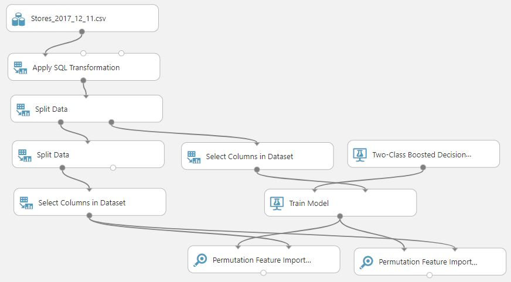

The Permutation Feature Importance module in Azure Machine Learning does not allow us to use our custom Precision * Recall metric. So, we run the module twice, once for Precision and once for Recall. Then, we determine which variables, also known as features, do not provide value for Precision or Recall. The results can be found in the “Store Churn Data Modeling Results.xlsx” file. Here is a summary:

| Variable Name | Precision PFI | Recall PFI |
| --- | --- | --- |
| TotalRevenue | 0.754623 | 0.153846 |
| TotalRevenue_Past3Months | 0.474503 | 0 |
| Status | 0.142292 | 0.061538 |
| Checkins_Evening | 0.100334 | 0 |
| Checkins_Hour6to7_Past3Months | 0.036232 | 0 |
| Checkins_Hour11to12_Past3Months | 0.036232 | 0 |
| ActiveUsers_Last3Months | 0.036232 | 0 |
| AverageMinsPerClass_Service | 0.036232 | 0 |
| Services | 0.036232 | 0 |
| Checkins_Hour8to9 | 0.023411 | 0 |
| Integration_Listen360 | 0.012422 | 0.030769 |
| Forms | 0.012422 | 0.030769 |
| Checkins_Monday | 0.005929 | 0.015385 |
| Checkins_Weekday | 0.005929 | 0.015385 |
| Checkins_Hour14to15 | 0.005929 | 0.015385 |
| Checkins_Morning | 0.005929 | 0.015385 |
| Checkins_Afternoon | 0.005929 | 0.015385 |
| Checkins_Monday_Past3Months | 0.005929 | 0.015385 |
| Checkins_Hour12to13_Past3Months | 0.005929 | 0.015385 |
| Checkins_Evening_Past3Months | 0.005929 | 0.015385 |
| ActiveEmployees_Last3Months | 0.005929 | 0.015385 |
| UserEmployeeRatio_Last3Months | 0.005929 | 0.015385 |
| ActiveEmployees | 0 | 0.015385 |

Any variables not included in this list did not show any importance for either metric. One concern here is that these zeroes are not actually zeroes. Instead, they represent very small numbers. So, when we drastically reduce our variable size, we do lose some power in our model. We can see this in the table below. For a review of the Test/Training sets, see previous section

**Full Variable Set**

| Test/Training Set | Precision | Recall | Precision * Recall |
| --- | --- | --- | --- |
| Set 1 | 0.893 | 0.384 | 0.343 |

**Precision/Recall Variable Set**

| Test/Training Set | Precision | Recall | Precision * Recall |
| --- | --- | --- | --- |
| Set 1 | 0.815 | 0.336 | 0.27384 |
| Set 2 | 0.767 | 0.287 | 0.220129 |
| Set 3 | 0.84 | 0.309 | 0.25956 |

Therefore, we ran another analysis to include the other two available evaluation metrics, Accuracy and Average Log Loss, understanding that they do not provide as much value as Precision and Recall to our analysis.

| Variable Name | Precision PFI | Recall PFI | Accuracy PFI | Average Log Loss PFI |
| --- | --- | --- | --- | --- |
| TotalRevenue | 0.754623 | 0.153846 | 0.041257 | 0.345677 |
| TotalRevenue_Past3Months | 0.474503 | 0 | 0.016699 | 0.032497 |
| Status | 0.142292 | 0.061538 | 0.003438 | 0.08103 |
| Checkins_Evening | 0.100334 | 0 | 0.001473 | 0 |
| Checkins_Hour6to7_Past3Months | 0.036232 | 0 | 0.000491 | 0 |
| Checkins_Hour11to12_Past3Months | 0.036232 | 0 | 0.000491 | 0 |
| ActiveUsers_Last3Months | 0.036232 | 0 | 0.000491 | 0.007357 |
| AverageMinsPerClass_Service | 0.036232 | 0 | 0.000491 | 0.001426 |
| Services | 0.036232 | 0 | 0.000491 | 0 |
| Checkins_Hour8to9 | 0.023411 | 0 | 0 | 0 |
| Integration_Listen360 | 0.012422 | 0.030769 | 0.000982 | 0.005943 |
| Forms | 0.012422 | 0.030769 | 0.000982 | 0.004854 |
| Checkins_Monday | 0.005929 | 0.015385 | 0.000491 | 0.005731 |
| Checkins_Weekday | 0.005929 | 0.015385 | 0.000491 | 0.002713 |
| Checkins_Hour14to15 | 0.005929 | 0.015385 | 0.000491 | 0.003422 |
| Checkins_Morning | 0.005929 | 0.015385 | 0.000491 | 0.003546 |
| Checkins_Afternoon | 0.005929 | 0.015385 | 0.000491 | 0.002234 |
| Checkins_Monday_Past3Months | 0.005929 | 0.015385 | 0.000491 | 0.000259 |
| Checkins_Hour12to13_Past3Months | 0.005929 | 0.015385 | 0.000491 | 0 |
| Checkins_Evening_Past3Months | 0.005929 | 0.015385 | 0.000491 | 0.00133 |
| ActiveEmployees_Last3Months | 0.005929 | 0.015385 | 0.000491 | 0 |
| UserEmployeeRatio_Last3Months | 0.005929 | 0.015385 | 0.000491 | 0 |
| ActiveEmployees | 0 | 0.015385 | 0 | 0.000637 |
| PurchasedSessions | 0 | 0 | 0 | 0.009245 |
| Amenities | 0 | 0 | 0 | 0.007819 |
| StoreAgeMonths | 0 | 0 | 0 | 0.003792 |
| UserEmployeeRatio | 0 | 0 | 0 | 0.002884 |
| Checkins_Thursday_Past3Months | 0 | 0 | 0 | 0.002714 |
| Checkins | 0 | 0 | 0 | 0.002576 |
| Checkins_Hour4to5 | 0 | 0 | 0 | 0.00185 |
| Checkins_Past3Months | 0 | 0 | 0 | 0.001458 |
| Checkins_Hour9to10 | 0 | 0 | 0 | 0.001359 |
| AveragePricePerService | 0 | 0 | 0 | 0.000855 |
| AveragePricePerClass_Service | 0 | 0 | 0 | 0.000808 |
| Checkins_Hour6to7 | 0 | 0 | 0 | 0.000788 |
| Checkins_Hour1to2_Past3Months | 0 | 0 | 0 | 0.000597 |
| Checkins_Hour13to14 | 0 | 0 | 0 | 0.000224 |
| NonRequiredWaiver | 0 | 0 | 0 | 0.000083 |
| Checkins_Hour17to18 | 0 | 0 | 0 | 0.000071 |
| Checkins_Saturday | 0 | 0 | 0 | 0.000013 |

If we include all of these variables in our model, we see some improvement that moves us closer to our original model.

**Full Variable Set (130 Variables)**

| Test/Training Set | Precision | Recall | Precision * Recall |
| --- | --- | --- | --- |
| Set 1 | 0.893 | 0.384 | 0.343 |

**Precision/Recall Variable Set (23 Variables)**

| Test/Training Set | Precision | Recall | Precision * Recall |
| --- | --- | --- | --- |
| Set 1 | 0.815 | 0.336 | 0.27384 |
| Set 2 | 0.767 | 0.287 | 0.220129 |
| Set 3 | 0.84 | 0.309 | 0.25956 |

**Precision/Recall/Accuracy/Average Log Loss Variable Set (40 Variables)**

| Test/Training Set | Precision | Recall | Precision * Recall |
| --- | --- | --- | --- |
| Set 1 | 0.88 | 0.338 | 0.29744 |
| Set 2 | 0.889 | 0.3 | 0.2667 |
| Set 3 | 0.96 | 0.353 | 0.33888 |

These numbers looks extremely promising. Given that the Users data contains all of these Store variables, we will wait until we see the Permutation Feature Importance results for the User Churn scenario before we decide which variables we will keep.

# Feature Engineering